# Project 2: Public Health & Epidemiology

Merrimack College DSE6630: Healthcare & Life Sciences Analytics

Vicky(Xin) Guo

1 June 2026

# 1 Introduction

It is **September of 2020**, right in the middle of the COVID-19 pandemic and during the California statewide shutdown. You have just been hired by the [California Department of Public Health (CDPH) in Vital Records](https://www.cdph.ca.gov/Programs/CHSI/Pages/Vital-Records.aspx) to track non-COVID mortality trends for the past 4 years for which all data have currently been aggregated and de-identified (anonymized). You are told that the purpose is two-fold:

1. **Help the state identify shifts in spatiotemporal mortality trends as a result of the COVID statewide stay-at-home orders.**
2. **Help the state build predictive models for non-COVID causes of mortality to establish a pre-COVID baseline.**

## 1.1 Provided data: California mortalities

You were given properly de-identified data from 2017 - 2020, which contain mortality records for the state of California by gender, leading cause of death, race / ethnicity, and location of death. All data have been taken from the death certificates filed with the state.

**NOTE**: If you are interested in these data, the source is the [California Death Profiles dataset](https://data.chhs.ca.gov/dataset/death-profiles-by-county) maintained by California Health and Human Services.

```r
## Load the provided data files
load("california_mortality_tables.RData")
```

You are provided 6 tables total, which have the following variables.

Table 1. Data dictionary of variables in the California mortality tables.

| **All Tables** |  |
| --- | --- |
| Year | Year of record |
| Month | Month of record |
| County | California county where death was recorded |
| **Annual Mortality Table** |  |
| annualCount | Number of deaths for the sex specified |
| raceEthnicity | Race and/or Ethnicity of the deceased; Latinx is unfortunately treated as a racial category here rather than an ethnic group |
| **Specialized Variables** |  |
| leadingCauseDeath | Leading cause of death per death certificate; See separate table for encoding |
| ageBins | Age groups where the age at death was known |
| ageDeaths | Number of deaths for the age bin specified |
| biologicalSex | Biological sex of decedent |
| sexDeaths | Number of deaths for the sex specified |
| placeDeathOccurred | Location of death, per death certificate |
| placeDeaths | Number of deaths matching specified criteria |
| raceDeaths | Number of deaths matching race / ethnic criteria |
| totalDeaths | Number of deaths per month, year, & county |

Table 2. Underlying cause of death category based on coding using the Tenth Revision of the International Classification of Diseases (ICD) codes

| 3-letter Code | Description | ICD-10 Codes |
| --- | --- | --- |
| HTD | Diseases of the Heart | I00-I09, I11, I13, I20-I51 |
| CAN | Malignant Neoplasms (Cancers) | C00-C97 |
| STK | Cerebrovascular Disease (Stroke) | I60-I69 |
| CLD | Chronic Lower Respiratory Disease (CLRD) | J40-J47 |
| INJ | Unintentional Injuries | V01-X59, Y85-Y86 |
| PNF | Pneumonia and Influenza | J09-J18 |
| DIA | Diabetes Mellitus | E10-E14 |
| ALZ | Alzheimer’s Disease | G30 |
| LIV | Chronic Liver Disease and Cirrhosis | K70, K73-K74 |
| SUI | Intentional Self Harm (Suicide) | U03, X60-X84, Y87.0 |
| HYP | Essential Hypertension and Hypertensive Renal Disease | I10, I12, I15 |
| HOM | Homicide | U01-U02, X85-Y09, Y87.1 |
| NEP | Nephritis, Nephrotic Syndrome and Nephrosis | N00-N07, N17-N19, N25-N27] |
| OTH | All Other Causes of Death | All codes not listed above |

**NOTE**: Make sure to refer to these tables as you go!

# 2 Using Spatial Analysis to Assess Spatiotemporal Trends in Overall Mortality

## 2.1 Background

Unlike your first project, your data engineering team (i.e., **me**) has provided you with most of the data tables in a nice, tidy format that are relatively nice and tidy to begin with - which means you can dig right into the analysis! Remember, any time you have datasets with **spatial information** they are spatial data; these data are organized by California county, so you know you must do a spatial analysis! However, there is also a *temporal* element - you have data from four different years, 2017 to 2020. So, you decide you will make maps to analyze both the spatial (geographic) and temporal (time) trends in the hope it will shed insight into which downstream analysis you should do. Consider this to be part of your **Exploratory Data Analysis**.

As discussed in lecture, one of the key types of spatial data files you might use are called **shapefiles**, which is what you are going to practice loading and working with shapefiles, using this [open source dataset](https://gis.data.ca.gov/datasets/2c4e32ee61824e28bd4cf37ecac96f39_0/explore?location=37.271891%2C-119.270269%2C5) for the state of California. You will have to download these data as they are too large to put onto GitHub. **NOTE**: Make sure you download the shapefiles only and decompress them!

Begin by downloading the requisite spatial data files. Make sure you put them in their own directory called **California_County_Boundaries2025** on your Desktop; otherwise, you will need to adjust your path in the file settings below! This is similar to what I had you do in Demo 1, if you’ll recall.

Notice that the directory contains six files, three of them with file extensions you discussed last week in lecture:

- `California_County_Boundary.cpg`
- `California_County_Boundary.dbf`
- `California_County_Boundary.prj`
- `California_County_Boundary.shp`
- `California_County_Boundary.shp.xml`
- `California_County_Boundary.shx`

#### Question 1 [1 point]:

What do each of these six files represent? You will not be able to open them directly on your computer, so you may need to refer back to lecture and do a little digging to figure out the type of data you would expect each of these files to contain.

**Answer:**

1. Here is exactly what each file in your California_County_Boundary set does:
- .shp: The main file that stores the actual geometric locations of the California county boundaries (the shapes themselves).
- .shx: The index file that stores the spatial index of the geometric features, allowing GIS software to quickly search and find the shapes.
- .dbf: A dBASE table file that stores the attribute data (e.g., the names of each California county, their land area, and FIPS codes) linked to the shapes.
- .prj: The projection file that contains the coordinate system and projection information, telling the software exactly where this California data sits on the Earth’s surface.
- .cpg: An optional file used to specify the character encoding (e.g., UTF-8) for identifying the text in the attribute table..shp.xml: An XML metadata file that stores information about the data’s source, how it was created, and its intended use.

## 2.2 Your objective

You want to first get a sense for **annual trends** in overall mortality across the state to see what you are working with. Your first objective is to join your overall mortality data to the shapefile to be able to make maps to visualize these trends. You also want to calculate **spatial weights** to allow you to create predictive models of mortality by county.

## 2.3 Making your first map of California

You are going to practice two ways to make maps from shapefiles so that you can see two ways to do it. Also, to give you more for reference, you are roughly following the GIS Basics Chapter of the Epi R Handbook (with your own twist, of course!). This chapter may be helpful for understanding more of the “nuts and bolts” of GIS as well, including definitions and why you might do things certain ways.

**The initial processing steps will include:**

1. Import the shapefile
2. Filter rows to keep only areas of interest
3. Merge with the other data tables to creates maps and analyze trends

### 2.3.1 Read in the shapefile & validate geometries

You will leverage the `read_sf()` function that is part of the `sf` package. As you might have guessed, `sf` refers to **shapefile**. Note that there is an alternative method to read in shapefiles called `st_read`, which is an alias for `read_sf()` with some different default arguments. By default, `read_sf()` is quiet, whereas `read_st()` will print information about the data source by default. Additionally, `read_sf()` returns a tibble rather than a dataframe. So which to choose? It’s your preference, in this case. By default, your code below will use `read_sf()` but you could instead use `read_st()` if you wanted.

```r
cali_sf <- read_sf("~/Development/R_workspaces/data_sources/California_County_Boundary_2026/California_County_Boundary.shp")

## Alternatively, you can read in the shapefile using the 'st_read()' function
## cali_st <- st_read("~/Downloads/California_County_Boundaries2025/California_County_Boundary.shp")
```

**NOTE** If you get a warning (as opposed to a critical error) is from [GDAL](https://gdal.org/en/stable/), a library of raster and vector geospatial data formats that your `read_sf()` (or `st_read()`) functions are using to transform the polygons for mapping. This warning indicates that some polygon geometries in the shapefile have boundaries (rings) with an inconsistent order of coordinates (“invalid winding order”). GIS tools assume that it will read from the right-hand, and the warning is letting you know that it is autocorrecting it. However, you could still have issues and it isn’t ideal.

*Just as you did in Demo 2, you can fix this by validating the polygon boundaries:*

```r
## Disable Google S2 engine
sf_use_s2(FALSE)
## Validate the geometry boundaries/edges
cali_sf <- st_make_valid(cali_sf)
```

*Now, let’s do a quick check of the map of California counties to make sure all the layers look okay:*

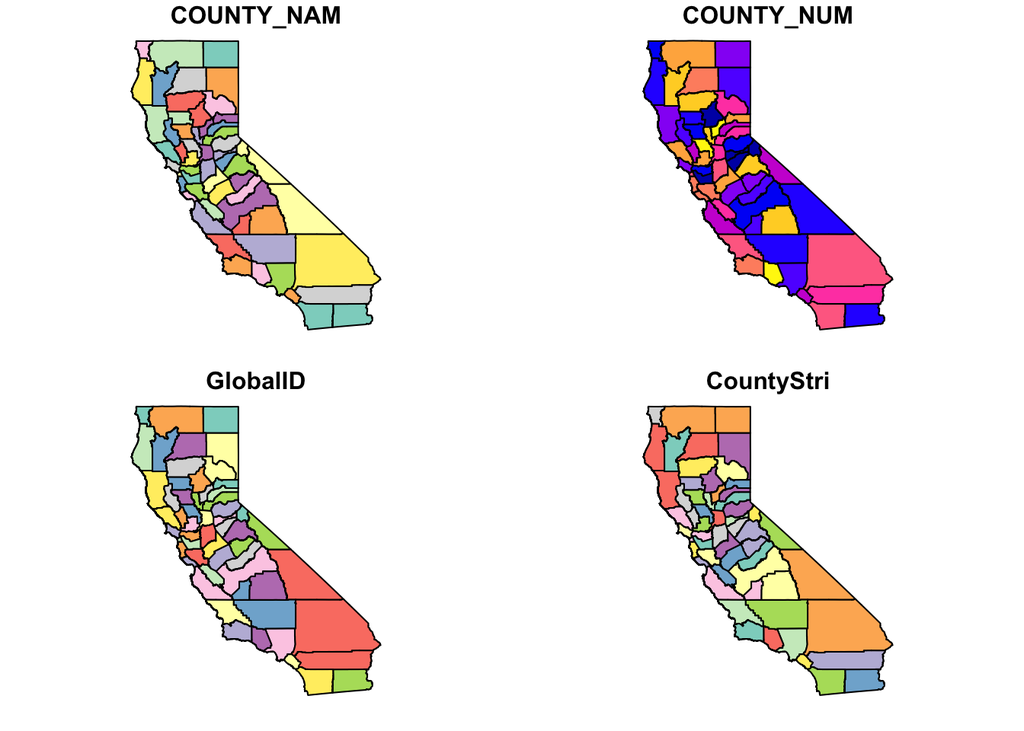

```r
plot(cali_sf)
```

*And let’s check the validity of the boundaries:*

```r
st_is_valid(cali_sf)
```

```
##  [1] TRUE TRUE TRUE TRUE TRUE TRUE TRUE TRUE TRUE TRUE TRUE TRUE TRUE TRUE TRUE
## [16] TRUE TRUE TRUE TRUE TRUE TRUE TRUE TRUE TRUE TRUE TRUE TRUE TRUE TRUE TRUE
## [31] TRUE TRUE TRUE TRUE TRUE TRUE TRUE TRUE TRUE TRUE TRUE TRUE TRUE TRUE TRUE
## [46] TRUE TRUE TRUE TRUE TRUE TRUE TRUE TRUE TRUE TRUE TRUE TRUE TRUE TRUE
```

```r
print(cali_sf$COUNTY_NAM)
```

```
##  [1] "Alpine"          "Amador"          "Butte"           "Calaveras"
##  [5] "Colusa"          "Contra Costa"    "Del Norte"       "El Dorado"
##  [9] "Fresno"          "Glenn"           "Humboldt"        "Imperial"
## [13] "Inyo"            "Kern"            "Kings"           "Lake"
## [17] "Lassen"          "Los Angeles"     "Madera"          "Marin"
## [21] "Mariposa"        "Mendocino"       "Merced"          "Modoc"
## [25] "Mono"            "Monterey"        "Napa"            "Nevada"
## [29] "Orange"          "Placer"          "Plumas"          "Riverside"
## [33] "Sacramento"      "San Benito"      "San Bernardino"  "San Diego"
## [37] "San Francisco"   "San Joaquin"     "San Luis Obispo" "San Mateo"
## [41] "Santa Barbara"   "Santa Clara"     "Santa Cruz"      "Shasta"
## [45] "Sierra"          "Siskiyou"        "Solano"          "Sonoma"
## [49] "Stanislaus"      "Sutter"          "Tehama"          "Trinity"
## [53] "Tulare"          "Tuolumne"        "Ventura"         "Yolo"
## [57] "Yuba"            "Alameda"         "Colusa"
```

#### Question 2 [1 point]:

Why did `TRUE` print 69 times? What are the “69 features” in the geometry?

**Hint 1**: Are all of them counties? Try running `print(calif_sf$COUNTY_NAME)`. What do you see?

**Answer:** st_is_valid() returns one logical per feature (one polygon record), this results return 59 features, I got 59 TRUEs. But California has only 58 counties — so the geometry holds more polygon features than there are counties.

So all 58 counties are present, but Colusa is duplicated. The 59 features are 58 counties plus one redundant Colusa polygon record.

*Next, let’s take a look at the geometry of the shapefile that you loaded.*

```r
cali_sf$geometry
```

```
## Geometry set for 59 features
## Geometry type: GEOMETRY
## Dimension:     XY
## Bounding box:  xmin: -13849230 ymin: 3833650 xmax: -12704990 ymax: 5162402
## Projected CRS: WGS 84 / Pseudo-Mercator
## First 5 geometries:
```

Notice that, just like Demo 2, you only have the **polygon** geometry in your shapefile. If you were to investigate further, you would find that currently there are no other geometries (e.g., lines or points) in this shapefile. You could add them and export the shapefile, if you ever needed to do so, like to share with someone else. For example, if you wanted to add points for the county seats of each county, you could add them based on longitude and latitude; similarly, you could add just points for major California cities, which I will demonstrate below.

#### Question 3A [0.5 points]:

What is the bounding box that comes with your shapefile and what does it tell us? **What would you do to the bounding box if you wanted to zoom in or out on a geographic feature?**

**Answer:** The bounding box is the rectangle that wraps around all of the geometry in the shapefile — just four numbers, xmin, ymin, xmax, and ymax, marking the western, southern, eastern, and northern edges of the data. Running st_bbox(cali_sf) , result above. The first thing that tells me is that these aren’t longitude/latitude degrees — they’re meters, because the shapefile is in a projected CRS (Web Mercator). The second thing it tells me is the geographic footprint of the data: that rectangle is essentially the four corners of California, so the box is confirming the file covers the whole state and nothing outside it. The bounding box is really just describing the extent of the data, so I wouldn’t edit it to zoom.

#### Question 3B [0.5 points]:

What is the projection? What does it tell you and why does projection matter? **What will change if you change the projection?**

**Answer：** The projection — the coordinate reference system, or CRS — is how the curved surface of the Earth gets flattened onto a flat 2D map. Running st_crs(cali_sf) shows Web Mercator (EPSG:3857), which matches the geometry being in meters rather than lon/lat degrees. Projection matters because flattening always distorts something (area, distance, or shape), and because every layer I overlay has to share a CRS or it won’t line up. If I changed it — say st_transform() to EPSG:4326 — the coordinates would switch to degrees, the map would reshape slightly, and any distances or areas would change, even though the actual places stay the same.

### 2.3.2 Create a basic map of California

In Demo 2, I showed you how to plot shapefiles using `ggplot2`’s `geom_sf()` function, and even though there are advanced mapping functions in R you could use you will stick with that for consistency, convenience, and speed.

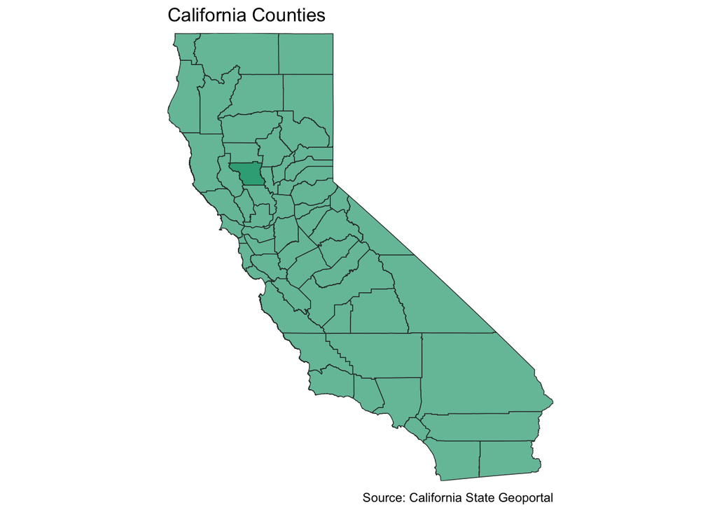

```r
## Initiate the plot and tell it the dataset
ggplot(data = cali_sf) +
  ## Give it specific fill and border colors
  geom_sf(fill = skittles[6],
          color = "gray20",
          linewidth = 0.25,
          alpha = 0.65) +

  ## Set map projection explicitly
  coord_sf(expand = FALSE) +   ## <- keeps map tight to its bounding box

  ## Uncomment to make a completely blank map background
  theme(
     panel.grid = element_blank(),
     panel.background = element_rect(fill = "white"),
     plot.background = element_rect(fill = "white"),
     axis.text = element_blank(),
     axis.ticks = element_blank(),
     axis.title = element_blank(),
   ) +

  ## Give it a title and footnote/caption
  labs(title = "California Counties",
       caption = "Source: California State Geoportal")
```

### 2.3.3 Zooming in on the map

Now, what if you only wanted to visualize a few counties? Let’s look at the three northernmost counties that border Oregon. The three northernmost California counties that border Oregon are:

- Del Norte
- Siskiyou
- Modoc

Notice that the county names are accessible through `cali_sf$COUNTY_NAM`. Thus, you can just use the `filter()` function from `dplyr` to be able to grab the three northernmost counties you want by name, which I have started for you.

#### Question 4 [1 point]:

Finish the code below to create a map of the northernmost 3 counties in California. You can copy and paste, with minor modifications, the code for the entire state map to do this. **NOTE** that you are storing your map into `map1`. This is because I will show you how to add labels in the next section! Don’t forget to update your plot title for full credit!

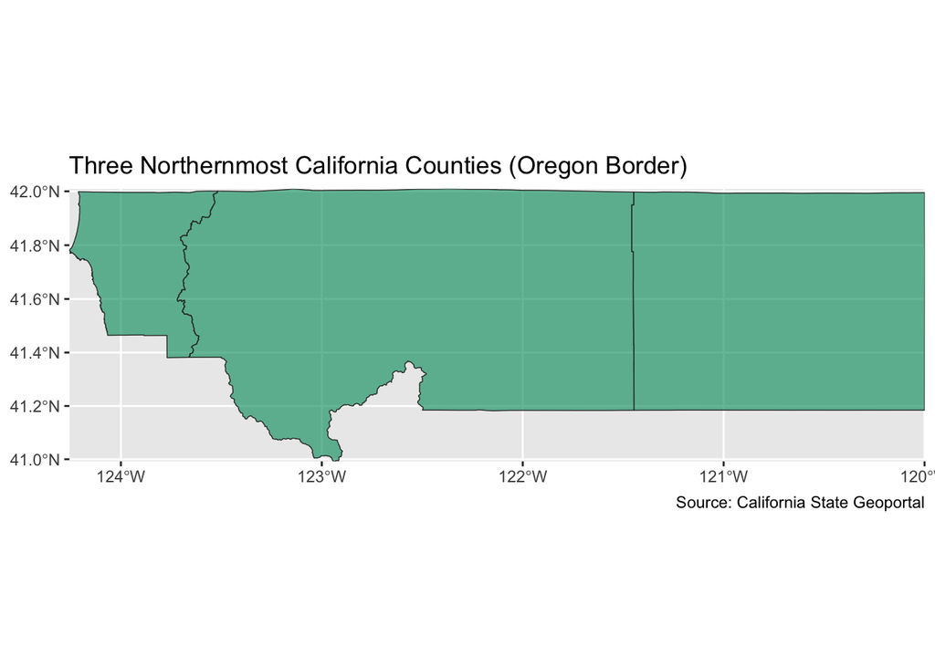

```r
# ## Start from the California spatial tibble - Uncomment to run
map1 <- cali_sf %>%
   ## Filter to just the 3 counties that border Oregon - Uncomment to run
   filter(COUNTY_NAM == "Del Norte" | COUNTY_NAM == "Siskiyou" | COUNTY_NAM == "Modoc") %>%
   ## Initiate the plot and tell it the dataset
   ggplot() +
    ## Give it specific fill and border colors
    geom_sf(fill = skittles[6],
            color = "gray20",
            linewidth = 0.25,
            alpha = 0.65) +

    ## Set map projection explicitly
    coord_sf(expand = FALSE) +   ## <- keeps map tight to its bounding box

    ## Give it a title and footnote/caption
    labs(title = "Three Northernmost California Counties (Oregon Border)",
         caption = "Source: California State Geoportal")

## Print it
map1
```

*Now let’s add labels!* This code will not run unless you have made `map1` correctly!

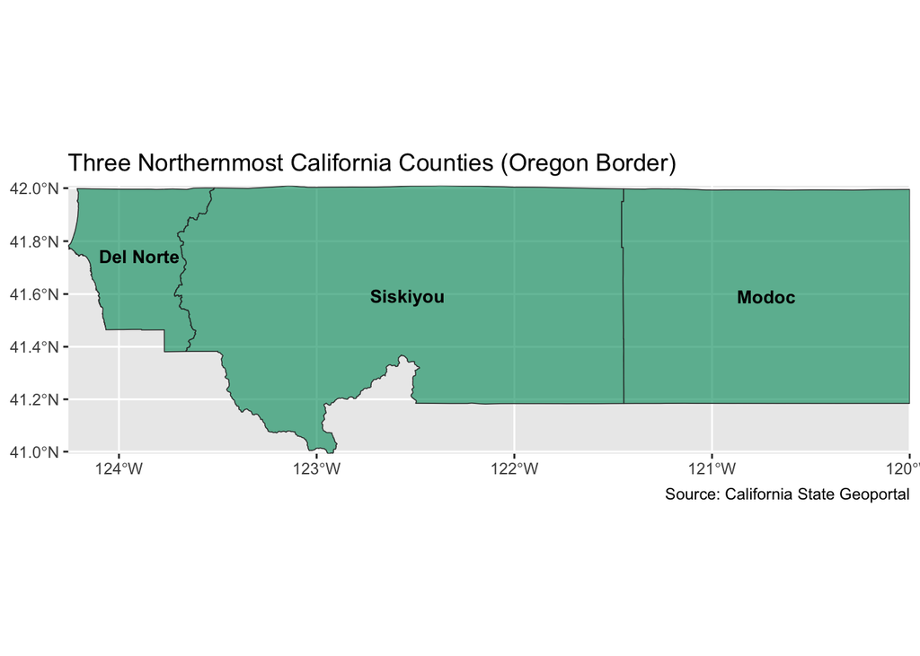

```r
## UNCOMMENT THIS CODE TO RUN:

 ## Calculate the county centers:
 county_centroids <- st_centroid(cali_sf) %>%
 ## Filter for just the northern centroids
     filter(COUNTY_NAM == "Del Norte" | COUNTY_NAM == "Siskiyou" | COUNTY_NAM == "Modoc")

 ## Now, add the labels to the map:
 map1 + geom_sf_text(data = county_centroids,
                     aes(label = COUNTY_NAM),
                     size = 3.5, fontface = "bold") +
   ## fix the x and y axis labels to make a beautiful map!
   theme(axis.title = element_blank())
```

## 2.3.4 Creating points for major cities in California

- Sacramento (the capital)
- Los Angeles
- San Diego
- San Francisco

But, to do this, it takes a little sorcery. You have to create a second **layer** for the points you want to overlay. So, you will put the longitude and latitude for each city, with the city’s name and an identifier as to whether it’s the capital or not, into its own dataframe. You will then convert it to a shapefile object.

```r
## Create a cities data frame with coordinates
cities <- data.frame(
  city = c("Sacramento", "San Diego", "Los Angeles", "San Francisco"),
  lon = c(-121.4944, -117.1611, -118.2437, -122.4194),
  lat = c(38.5816, 32.7157, 34.0522, 37.7749),
  cityType = c("capital", "major", "major", "major")
)

## Convert to shapefile object with the same projection as what you had
cities_sf <- st_as_sf(cities, coords = c("lon", "lat"), crs = 4326)
```

*Now, you can plot the map by overlaying the city points, with differing colors for each city and a different shape and size marker for the capital, Sacramento:*

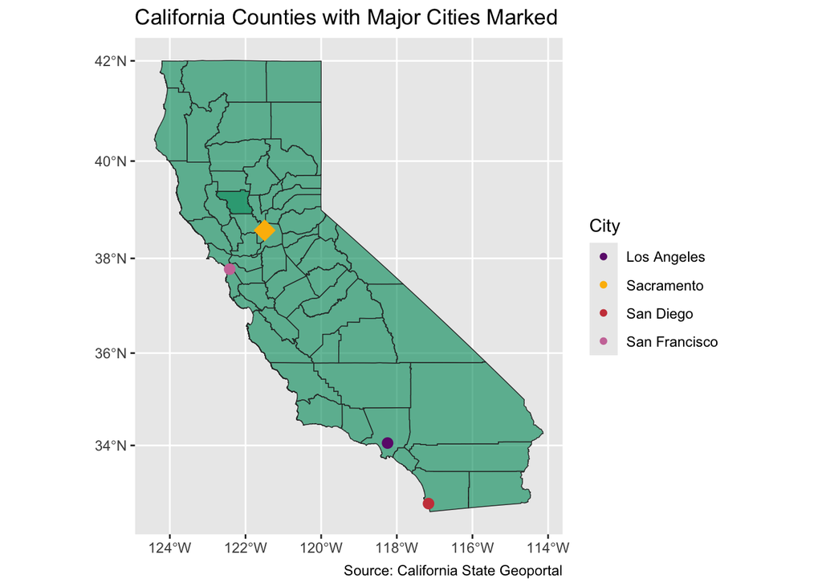

#### Question 5 [1 point]:

Your stakeholders point out that you have forgotten San Jose, one of the most populated cities in California! They ask you to go back to the map and add it on.

**Hint 1**: The coordinates of San Jose are 37.3387° N, 121.8853° W **Hint 2**: Don’t forget to add a `cityType` for San Jose! **Hint 3**: Don’t forget to add a skittles color for San Jose in `scale_color_manual`!

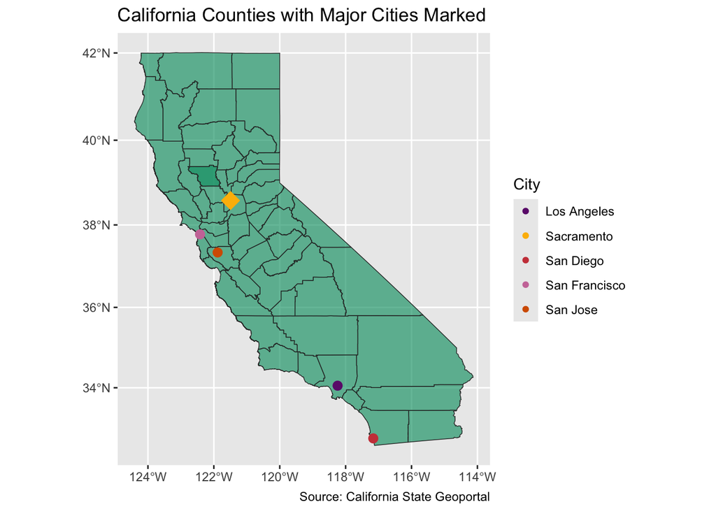

```r
## Create a cities data frame with coordinates
cities <- data.frame(
  city = c("Sacramento", "San Diego", "Los Angeles", "San Francisco", "San Jose"),
  lon = c(-121.4944, -117.1611, -118.2437, -122.4194, -121.8853),
  lat = c(38.5816, 32.7157, 34.0522, 37.7749, 37.3387),
  cityType = c("capital", "major", "major", "major", "major")
)

## Convert to shapefile object with the same projection as what you had
cities_sf <- st_as_sf(cities, coords = c("lon", "lat"), crs = 4326)

# Plot California counties with city points
ggplot(data = cali_sf) +
  ## Give it specific fill and border colors
  geom_sf(fill = skittles[6],
          color = "gray20",
          linewidth = 0.25,
          alpha = 0.65) +

  ## Set ap projection explicitly
  coord_sf(expand = FALSE) +   ## <- keeps map tight to its bounding box

  #### ----- Here is where you overlay the points! -------- ####
  geom_sf(data = cities_sf,
          ## Different colors & shapes & sizes for different cities
          aes(color = city, shape = cityType, size = cityType)) +

  ## Define shapes and sizes manually for cityType
  scale_shape_manual(values = c(capital = 18, major = 16), guide = "none") +
  scale_size_manual(values = c(capital = 6, major = 3), guide = "none") +

  ## Define the fill color for the city shapes
  scale_color_manual(values = skittles[1:5], name = "City") +

  ## Give it a title and footnote/caption
  labs(title = "California Counties with Major Cities Marked",
       caption = "Source: California State Geoportal")
```

#### Question 6 [1 point]:

Annotate the following code chunk with comments to make sure you understand what you are doing here. **HINT**: refer back to the earlier tables with the data descriptions to help you understand the data better!

```r
## Use the totalDeaths dataset because it contains mortality counts by county,
## year, and month, allowing us to visualize spatial and temporal trends.
mortality_sf <- totalDeaths %>%
  ## Rename County so that it matches the county name field in the California shapefile
  rename(COUNTY_NAM = County) %>%
  ## Group observations by county, year, and month so deaths can be summarized
  group_by(COUNTY_NAM, Year, Month) %>%
  ## Calculate the total number of deaths for each county-month combination
  summarise(totalDeaths = sum(totalDeaths, na.rm = TRUE)) %>%
  ## Join the mortality data to the California shapefile.
  ## A many-to-many relationship is specified because each county has multiple
  ## records (one for each month and year), and each county polygon in the
  ## shapefile may correspond to multiple mortality observations.
  full_join(cali_sf, by = "COUNTY_NAM", relationship = "many-to-many") %>%
  ## Convert the joined object back to an sf object so it can be used for mapping
  st_as_sf()
```

#### Question 7A [0.5 points]:

What does `st_join()` do? Could you have executed the join with `st_join()` instead of `full_join()` here? Why or why not?

**Answer:** st_join() joins data based on spatial relationships between geometries. It would not be appropriate here because the mortality data is being matched to counties using a common county name column, not geographic location. Therefore, full_join() is preferred over st_join().

#### Question 7B [0.5 points]:

This question has three subparts.

1. How many features are there in `mortality_sf`?

```r
nrow(mortality_sf)
```

```
## [1] 2596
```

2. Why are there so many more than in `cali_sf`?

**Answer:** cali_sf holds just one polygon per county (geometry only), so it has ~59 features. But totalDeaths has one row per county per month per year, and the join replicates each county’s geometry across every one of those time slices. With four years of data — 2017, 2018, and 2019 at twelve months each, plus 2020 at only eight months (January–August) — there are 44 month-year combinations, and 58 counties × 44 ≈ 2,500+ rows. So the feature count exploded not because there are more places, but because the same geometry is now repeated once for every point in time. (The duplicate Colusa record nudges it a little higher still, since its rows get matched twice.)

3. How many counties are there now in `COUNTY_NAM`? (Hint: Use `unique()` or `n_distinct()` to help you get the true number!) Why is it different from the number you saw in Question 2?

```r
n_distinct(mortality_sf$COUNTY_NAM)
```

```
## [1] 58
```

**Answer:** There are 58 distinct counties now, even though Q2 reported 59 features. The difference is that Q2 counted polygon features — and that count included the duplicate Colusa record — whereas n_distinct() counts unique county names. California really only has 58 counties, so the “extra” feature in Q2 was the duplicated Colusa polygon, not a real 59th county. It’s the same row-count-vs-entity-count distinction from before: 58 unique places, but more than 58 rows representing them.

## 2.5 Visualizing annual trends in overall mortality

You are asked to make four maps, one for each year, that shows how annual overall mortality trends to identify any changes as a result of either the COVID-19 pandemic or the stay-at-home orders. Notice that you first use a `group_by()` and a `summarize()` to tally the total deaths per county per year - but **unlike your previous chloropeths**, you are applying a purposeful set of cuts every $5 \times 10^n$ deaths. Why? This is to allow you to see [order of magnitude](https://en.wikipedia.org/wiki/Order_of_magnitude) changes in the total deaths by California counties for each of the four years.

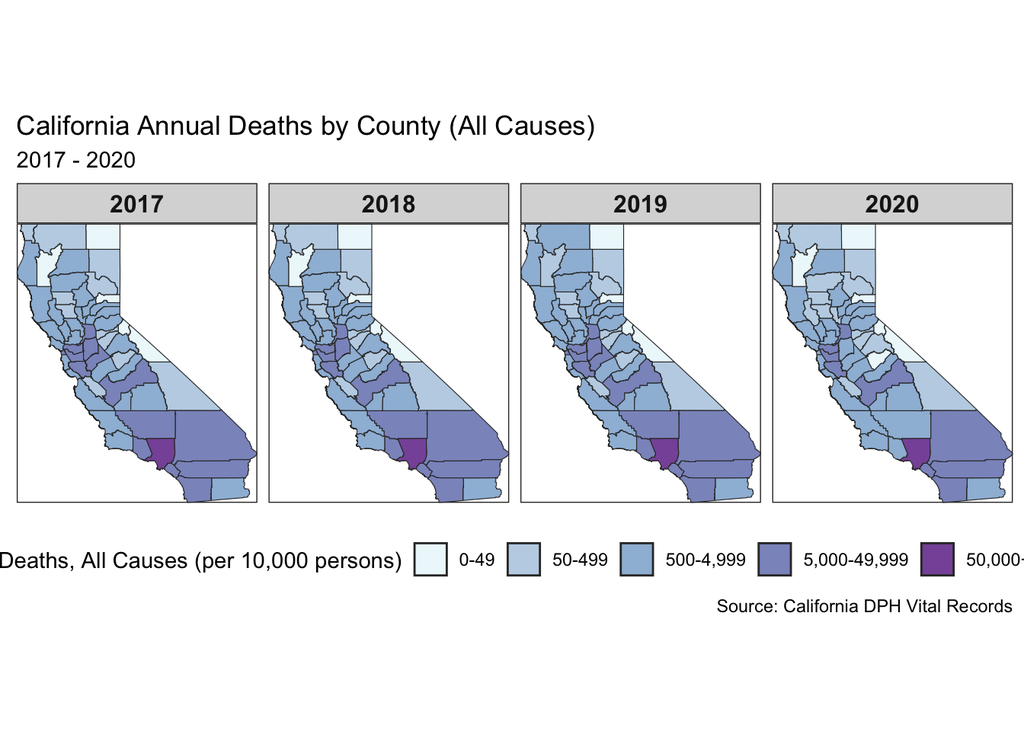

```r
## Start from the mortality spatial tibble
mortalitySummary <- mortality_sf %>%
  ## Group by and then summarize to total the deaths by County and Year
  group_by(COUNTY_NAM, Year) %>%
  summarise(totalDeaths = sum(totalDeaths, na.rm = TRUE)) %>%
  mutate(deathLabels = cut(totalDeaths,
                          breaks = c(0, 50, 500, 5000, 50000, Inf),
                          labels = c("0-49", "50-499", "500-4,999",
                                    "5,000-49,999", "50,000+"),
                          ordered_result = TRUE, right = F))
## Initialize the plot
ggplot(mortalitySummary) +
  ## Chloropeth: draw the polygons of the counties and color by total deaths
  geom_sf(aes(fill = deathLabels), color = "gray20", size = 0.2) +
  ## Apply manual fill scale for total deaths
  scale_fill_manual(
    name = "Deaths, All Causes (per 10,000 persons)",
    values = c4a(palette="BuPu", n=6),
    drop = FALSE
  ) +
  ## Set map projection explicitly
  coord_sf(expand = FALSE) +   ## <- keeps map tight to its bounding box
  theme_bw() +
  ## Make a completely blank map background this time
  theme(
    panel.grid = element_blank(),
    panel.background = element_rect(fill = "white"),
    plot.background = element_rect(fill = "white"),
    axis.text = element_blank(),
    axis.ticks = element_blank(),
    axis.title = element_blank(),
    strip.text = element_text(size = 12, face = "bold"),
    legend.position = "bottom"
  ) +
  labs(
    title = "California Annual Deaths by County (All Causes)",
    subtitle = "2017 - 2020",
    caption = "Source: California DPH Vital Records"
  ) +
  ## Use facet_wrap to make one map per year
  facet_wrap(~ Year, ncol = 4)
```

### 2.5.1 Uh oh, can you spot the problem?

#### Question 8 [1 point]:

Is there any pattern that is a cause for concern in your interpretation of **total deaths**?

**Hint 1**: The county with the highest number of deaths (darkest purple) is **Los Angeles county**. What is special about LA county? **Hint 2**: Do you see other similar darker colors in counties around cities?

**Answer:** Yes, LA County is the darkest purple in every year, but that’s not because LA is uniquely deadly, it’s because roughly 10 million people live there, far more than any other country in California. the same thing shows up everywhere else: the other darker counties are the Bay Area, San Diego, Sacramento, and the big Central Valley counties, more population area as well. while the rural northern and eastern counties like Modoc, Alpine, and Sierra stay the palest, because hardly anyone lives there to begin with.

So the cause for concern is that raw total deaths confounds mortality with population size. But I think we need more dig into to get the details.

## 2.6 Accessing the 2020 US Census API

Hopefully, you have figured out that you need population data to add to your dataframes. In Demo 2, I gave you Census data - but this time, I want to teach you how to more efficiently and iteratively access data through an **API** (Application Programming Interface), which acts as a bridge between two software programs to exchange data. As data scientists, learning to use and love APIs will serve you well! *Thus, for the Census data this time you are going to access the Census Bureau’s API endpoint.*

If you have not yet worked with an API, never fear! That’s why we’re doing it here. Here, the Census API will allow you to access their database and download their data in JSON (Java Script Object Notation) format, which is format that **flattens** databases into text. By connecting to the API endpoint for the Census Bureau, you will be able to download instantaneously only the data you want, which in your case will be population sizes and some basic demographics about the breakdown of population by sex and by individuals over the age of 65 years.

Because the US Census API uses JSON formatted files, you will be using the `jsonlite` package to convert the JSON files to a dataframe. But first, you need to gain access to the API!

### 2.6.1 Getting your first Census API Key (unless you already have one)

In order to access the Census API, you will need your own Census API key. I could give you mine, but it’s generally not good practice to share API keys unless you trust the person. Why? (1) If someone misuses your API key, you could get banned from accessing the API. (2) Especially for government or non-profit agencies, it can be a good idea to have your own so that they can keep track of how many users they have. Not all API access is free, but for government, non-profit, or institutionally held data, access is free although you may have different hoops to jump through for access depending on how secure they want to keep the data. (e.g., to protect survey respondents).

#### Question 9 [1 point]:

You will sign up for your API census key [here](https://api.census.gov/data/key_signup.html). You should be able to obtain your key very quickly, but if you run into trouble then I will give you the data I have downloaded through **my** API key so that you can still keep going with the project.

Once your have your key, fill it into this code chunk here:

```r
## Set your API key (put it between the quotation marks):
key <- "134960b4950e74688fa33e91decfece251ff689f"
```

### 2.6.2 Downloading data tables from the 2020 Census API

You are going to use the 2020 Census since that is the last year of data you have for the mortality dataset. The U.S. Census maintains numerous tables you can use for data. You will be using the **Decennial Census: Demographic Profile**. You can find the variable explanations for this table of the 2020 Census data here. Below is a custom function I have written that will allow you to extract any of the variables you want from this table as long as you follow the usage.

**HOW TO GET DATA FROM AN API: THE `url`**

The important thing to understand about APIs is that they are based on the `url` to the API endpoint. For example,

`https://api.census.gov/data/2020/dec/dp?get=NAME,DP1_0001C,DP1_0025C&for=county:*&in=state:06&key=YOUR_API_KEY`

is a `url` that you can break down into its constituent parts like this:

| Component | Description |
| --- | --- |
| `https://api.census.gov/data` | Base API endpoint |
| `/2020/dec/dp` | Specific dataset path (2020 Decennial Census, Data Profile) |
| `?get=NAME,DP1_0001C,DP1_0025C` | Variables to retrieve (`NAME` and 2 demographic variables, `DP1_0001C` and `DP1_0025C`) |
| `&for=county:*` | Requesting data for **all counties** |
| `&in=state:06` | Restricting to **California** (FIPS code 06) |
| `&key=YOUR_API_KEY` | Your **personal API key** (required for access) |

You can practice modifying this `url` by adding your personal key to the end. If you do, what you’ll see is something is this if you copy and paste the **completed `url`** into your browser:

[figure not shown]

This is the Census data for the two variables chosen in `JSON` format! You can then convert these into a dataframe using the `fromJSON()` function from the `jsonlite` library, although this is not the only `JSON` handling package that exists in R. Similar packages exist in Python.

**HOW THE FUNCTION WORKS**

The custom function, `getPopSizes()`, pulls population data from the U.S. Census API for all counties in California, specifically demographic details like total population, gender counts, and age 65+ breakdowns from the 2020 Decennial Census.

*Before you run the function, you must set the stage:*

- `state = "06"`
  - Sets the state FIPS code for California (FIPS 06 = CA)
  - If you wanted all states, you’d use “*”
- `vars`
  - A vector of Census variable codes for population totals, age, and sex breakdowns
  - For example, `DP1_0001C` is total population
- `header`
  - A human-readable list of column names that will replace the technical variable codes in `vars`

#### Question 10A [0.5 points]:

Using a search engine or the [Census table explorer](https://data.census.gov), whichever you find easier to use, look for the differences between table variables `DP1_0048C` and `DP1_0048P`. What different information do these two variables hold?

**Answer:** Both variables describe the same group — males aged 65 and older — but they report it in different units. DP1_0048C is the count: the actual number of men 65+ living in the county. DP1_0048P is the percent: that same group expressed as a percentage of the total.

*Digging into the Function*

The function `getPopSizes()` takes in the following information as **arguments** to be able to run correctly:

- `key`: your Census API key
- `vars`: variable codes
- `header`: column names you want

Then, inside the function, it is doing several key tasks:

1. Builds the `url` for the API request
- Adds variables to `get=...`
- Limits to counties in California via `for=county:*&in=state:06`
- Appends the API key at the end of the `url`
2. Requests the data from the Census API using `fromJSON(url)` and converts it to a data frame
3. Cleans the data for you
- Removes the first row (which contains column names from the API)
- Renames columns using `header`
- Converts character columns back into numbers (`mutate_at`)
4. Returns a cleaned data frame of all the census variables requested, complete with human-readable headers!
- This dataframe is now ready to be joined with your mortality shapefile!

**Function call** This line runs the function using your API key and saves the result to a variable called `census`: `census <- getPopSizes(key, vars, header)`

**NOTE** Make sure to change `include=FALSE` to `TRUE` in the first line (the `{r}` setup line) the chunk or you will get an error upon knitting.

```r
## Set the state want you in double-digit FIPS; if you want all states, use *
state = "06" ## California

## Set a vector of variables you want; no need to include NAME,
## it's already written into the function
vars <- c("DP1_0001C", "DP1_0025C", "DP1_0049C", "DP1_0024C",
          "DP1_0024P", "DP1_0048C", "DP1_0048P", "DP1_0072C",
          "DP1_0072P")

## Set my header
header <- c("totalN", "malesN", "femalesN", "over65", "over65perc",
            "males65plus", "males65plusPerc", "females65plus",
            "females65plusPerc")

getPopSizes <- function(key, vars, header) {
  ## Building your url

  ## initialize "get" variable
  get <- "NAME"
  ## For each of the variable, add in the codes to the "get" variable so you can
  ## add that into the API address
  for(i in 1:length(vars)){
    get <- paste(get, vars[i], sep="&")
  }
  ## Add in more of the necessary pieces into the API address
  for.statemt <- paste0("&for=county:*&in=state:", state)
  base.url <- "https://api.census.gov/data/2020/dec/dp"
  ## The finished URL that you will use to get the JSON file
  url <- paste0(base.url, "?get=", get, for.statemt, "&key=", key)

  ## Use fromJSON() to get the data table and turn into a data frame
  census <- data.frame(fromJSON(url))
  census <- census[-1, ]  ## first row needs to be dropped

  ## Rename the columns with what you want
  names(census) <- c("NAME", header, "STATE", "COUNTY")

  ## Fix the fact that everything numeric was turned into character
  census <- census %>%
      mutate_at(header, as.numeric)

  ## Done!
  return(census)
}

## Call the function
census <- getPopSizes(key, vars, header)
## Remove the extra characters from the name of the county
census <- census %>%
  mutate(NAME = gsub(" County, California", "", NAME)) %>%
  rename(County = NAME)
```

**Did you notice how quickly it accessed the information?** That is one of the strengths of APIs. You also get to customize the tables to only grab what you want and you can imagine how you might iterative over multiple years or other structures using a function similar to what I coded for you above. APIs are wonderful to become familiar with as a data scientist; I highly recommend practicing more with APIs as you move toward the job market as it is a highly sought after skill! I also strongly recommend the R package [`tidycensus`](https://walker-data.com/tidycensus/); I did not choose to use that here so you would have **generic code** you could use for many API endpoints going forward in your career! Additionally, `tidycensus` is restrictive since it only access some tables of the Census (notably the American Community Survey or ACS), but you were using a different table here.

#### Question 10B [0.5 points]:

Use code or some other method to explore the resulting dataframe, `census`. Explain what this dataframe contains.

**Answer:** the census dataframe has 58 rows — one per California county — and 12 columns. It contains the county name, total population (totalN), the population split by sex (malesN, femalesN), and the 65-and-over population as both counts and percentages, broken out overall and by sex (over65, males65plus, females65plus, plus their …perc versions). The last two columns, STATE and COUNTY, are FIPS codes used as join keys.

```r
census <- readRDS("census.rds") #save to file to avoid failed on knit

dim(census)        # rows x columns
```

```
## [1] 58 12
```

```r
#names(census)      # column names

head(census)       # first few counties
```

```
##      County  totalN malesN femalesN over65 over65perc males65plus
## 2   Alameda 1682353 824426   857927 240483       14.3      106747
## 3    Alpine    1204    633      571    301       25.0         160
## 4    Amador   40474  22067    18407  11480       28.4        5712
## 5     Butte  211632 104641   106991  40155       19.0       18494
## 6 Calaveras   45292  22754    22538  12762       28.2        6220
## 7    Colusa   21839  10996    10843   3251       14.9        1536
##   males65plusPerc females65plus females65plusPerc STATE COUNTY
## 2            12.9        133736              15.6    06    001
## 3            25.3           141              24.7    06    003
## 4            25.9          5768              31.3    06    005
## 5            17.7         21661              20.2    06    007
## 6            27.3          6542              29.0    06    009
## 7            14.0          1715              15.8    06    011
```

```r
glimpse(census)
```

```
## Rows: 58
## Columns: 12
## $ County            <chr> "Alameda", "Alpine", "Amador", "Butte", "Calaveras",…
## $ totalN            <dbl> 1682353, 1204, 40474, 211632, 45292, 21839, 1165927,…
## $ malesN            <dbl> 824426, 633, 22067, 104641, 22754, 10996, 568066, 15…
## $ femalesN          <dbl> 857927, 571, 18407, 106991, 22538, 10843, 597861, 12…
## $ over65            <dbl> 240483, 301, 11480, 40155, 12762, 3251, 192799, 5241…
## $ over65perc        <dbl> 14.3, 25.0, 28.4, 19.0, 28.2, 14.9, 16.5, 18.9, 22.3…
## $ males65plus       <dbl> 106747, 160, 5712, 18494, 6220, 1536, 85071, 2507, 2…
## $ males65plusPerc   <dbl> 12.9, 25.3, 25.9, 17.7, 27.3, 14.0, 15.0, 16.7, 21.6…
## $ females65plus     <dbl> 133736, 141, 5768, 21661, 6542, 1715, 107728, 2734, …
## $ females65plusPerc <dbl> 15.6, 24.7, 31.3, 20.2, 29.0, 15.8, 18.0, 21.5, 23.0…
## $ STATE             <chr> "06", "06", "06", "06", "06", "06", "06", "06", "06"…
## $ COUNTY            <chr> "001", "003", "005", "007", "009", "011", "013", "01…
```

```r
summary(census)    # ranges for the numeric columns
```

```
##     County              totalN             malesN           femalesN
##  Length:58          Min.   :    1204   Min.   :    633   Min.   :    571
##  Class :character   1st Qu.:   47874   1st Qu.:  24263   1st Qu.:  23611
##  Mode  :character   Median :  186670   Median :  92475   Median :  94428
##                     Mean   :  681694   Mean   : 337052   Mean   : 344642
##                     3rd Qu.:  711551   3rd Qu.: 351299   3rd Qu.: 360252
##                     Max.   :10014009   Max.   :4906513   Max.   :5107496
##      over65          over65perc     males65plus     males65plusPerc
##  Min.   :    301   Min.   :10.60   Min.   :   160   Min.   : 9.10
##  1st Qu.:  11558   1st Qu.:14.35   1st Qu.:  5721   1st Qu.:12.90
##  Median :  31845   Median :16.60   Median : 14372   Median :15.35
##  Mean   : 103744   Mean   :18.71   Mean   : 46502   Mean   :17.47
##  3rd Qu.: 105460   3rd Qu.:22.55   3rd Qu.: 47380   3rd Qu.:21.50
##  Max.   :1453950   Max.   :30.90   Max.   :637029   Max.   :30.20
##  females65plus    females65plusPerc    STATE              COUNTY
##  Min.   :   141   Min.   :12.40     Length:58          Length:58
##  1st Qu.:  5837   1st Qu.:15.60     Class :character   Class :character
##  Median : 17496   Median :18.25     Mode  :character   Mode  :character
##  Mean   : 57243   Mean   :20.00
##  3rd Qu.: 57500   3rd Qu.:23.50
##  Max.   :816921   Max.   :32.40
```

#### Question 11 [1 point]:

Now that you know more generally how this function works and have seen it in action, in your own words, explain how you could adapt this approach (or even this function!) to work with a different API (not the Census). I am not asking you to code, but I am asking you to think through:

1. What key pieces of the function would you need to change?
2. What general steps stay the same regardless of the API?
- **Hint 1**: Think about how the `url` is built and what makes it specific to the Census API.
- **Hint 2**: Think about how the data is retrieved (e.g., using `fromJSON()`) and cleaned afterward.
- **Hint 3**: For simplicity, assume that the data retrieved are in `JSON` format, since that is the most commonly used format.

**Answer:** An API is just a consistent, reusable contract for requesting data: you send a URL with parameters, and the API returns a structured result. So this function is really a reusable pattern, not Census-specific logic — only the configuration changes from one API to the next.

What I’d change is mostly that configuration: the base endpoint, the query parameters, and how they’re named, since each API has its own way of specifying what you want and how to filter it. For example, the Census uses ?get=…&for=county:*&in=state:06, but another API would have completely different parameter names and filtering syntax. The field codes would change too — swapping the DP1_xxxx variables for the new API’s fields to get different results — and the authentication might differ (the Census puts the key in the URL, while many APIs use a header or token instead). What stays the same is the overall flow: build a URL from the arguments, send the request, parse the returned JSON into a dataframe (JSON being the common format today), then clean it up — renaming columns and fixing types — and return a tidy result. Different parameters just produce different results from the same reusable pattern.

### 2.6.3 Joining the census with the spatial data and updating the maps

#### Question 12 [3 points]:

Now, it’s your turn to do some work! Your task is to join the census data to the shapefile of overall mortality we’ve already made. You want a tibble that contains all of the data from the census dataframe and all of the data from `mortality_sf`. I called mine `mortality_sf2`, so you will want to call yours the same unless you plan to change the variable name everywhere else downstream.

- **Hint 1**: The easiest way is to use the FIPS data to join.
- **Hint 2**: Don’t worry about calculating % mortality yet. I will help you with that below.
- **Hint 3**: If you’re having problems, check your data types!

```r
#glimpse(mortality_sf)
#glimpse(census)

mortality_sf2 <- mortality_sf %>%
  ungroup() %>%
  ## census$County matches mortality's COUNTY_NAM; rename so it's the join key
  left_join(census %>% rename(COUNTY_NAM = County), by = "COUNTY_NAM") %>%
  st_as_sf()

nrow(mortality_sf2)
```

```
## [1] 2596
```

```r
dplyr::n_distinct(mortality_sf2$COUNTY_NAM)
```

```
## [1] 58
```

```r
sum(is.na(mortality_sf2$totalN))
```

```
## [1] 0
```

```r
glimpse(mortality_sf2)
```

```
## Rows: 2,596
## Columns: 19
## $ COUNTY_NAM        <chr> "Alameda", "Alameda", "Alameda", "Alameda", "Alameda…
## $ Year              <int> 2017, 2017, 2017, 2017, 2017, 2017, 2017, 2017, 2017…
## $ Month             <int> 1, 2, 3, 4, 5, 6, 7, 8, 9, 10, 11, 12, 1, 2, 3, 4, 5…
## $ totalDeaths       <int> 1048, 831, 880, 859, 852, 772, 807, 750, 769, 811, 7…
## $ COUNTY_NUM        <dbl> 1, 1, 1, 1, 1, 1, 1, 1, 1, 1, 1, 1, 1, 1, 1, 1, 1, 1…
## $ GlobalID          <chr> "6341ecf5-b0ec-4a0c-94dc-05b8b0505dae", "6341ecf5-b0…
## $ CountyStri        <chr> "1", "1", "1", "1", "1", "1", "1", "1", "1", "1", "1…
## $ geometry          <POLYGON [m]> POLYGON ((-13611182 4566017..., POLYGON ((-1…
## $ totalN            <dbl> 1682353, 1682353, 1682353, 1682353, 1682353, 1682353…
## $ malesN            <dbl> 824426, 824426, 824426, 824426, 824426, 824426, 8244…
## $ femalesN          <dbl> 857927, 857927, 857927, 857927, 857927, 857927, 8579…
## $ over65            <dbl> 240483, 240483, 240483, 240483, 240483, 240483, 2404…
## $ over65perc        <dbl> 14.3, 14.3, 14.3, 14.3, 14.3, 14.3, 14.3, 14.3, 14.3…
## $ males65plus       <dbl> 106747, 106747, 106747, 106747, 106747, 106747, 1067…
## $ males65plusPerc   <dbl> 12.9, 12.9, 12.9, 12.9, 12.9, 12.9, 12.9, 12.9, 12.9…
## $ females65plus     <dbl> 133736, 133736, 133736, 133736, 133736, 133736, 1337…
## $ females65plusPerc <dbl> 15.6, 15.6, 15.6, 15.6, 15.6, 15.6, 15.6, 15.6, 15.6…
## $ STATE             <chr> "06", "06", "06", "06", "06", "06", "06", "06", "06"…
## $ COUNTY            <chr> "001", "001", "001", "001", "001", "001", "001", "00…
```

**Note**: If you’re unable to do this for any reason, you can pick back up here. You will need to download the data from [Google Drive](https://drive.google.com/file/d/15MT127zoySDS7kOfr9uhLwPSIWBCok1W/view?usp=sharing), as the shapefile is too large for GitHub yet again. I have placed mine on my Desktop, but you can put it anywhere you like and update the directory path. Just make sure not to put it in your GitHub repo!

```r
## Comment me out or change EVAL=FALSE to run your own versions!
##load("~/Desktop/mortality_sf2.Rdata")
##load("census.Rdata")
```

## 2.7 Mapping population-adjusted mortality

Now, at this point, you were so excited to have these data that you decide to next calculate the annual population-adjusted % mortality per county per year so that you could recreate the map you tried to make above. **Notice** that, this time, I set the color scale for the chloropeth to equal the **five number summary** from `fivenum()` so that you could more easily see the median versus the quartiles.

**NOTE**: If you get errors here, it is because your `mortality_sf2` object is not quite right!

```r
##### Calculate the annual percent mortality
mortalitySummary <- mortality_sf2 %>%
  ## Group by County as well as Year
  group_by(COUNTY_NAM, Year) %>%
  ## Summarize by calculating an annual percent mortality
  ## Note that I have to divide by the mean of the N from the Census
  ## or I'd get an error
  summarize(annualPercMortality = 100*(sum(totalDeaths,
                                           na.rm = TRUE)/mean(totalN))) %>%
  ## Ungroup - necessary to remove the grouping for future use
  ungroup()

#### Find the five number summary
summ <- fivenum(mortalitySummary$annualPercMortality)
paste0("The five-number summary of annual % total mortality is: ")
```

```
## [1] "The five-number summary of annual % total mortality is: "
```

```r
paste(c("Min", "Lower Quartile", "Median", "Upper Quartile", "Max"),
      round(summ, 3))
```

```
## [1] "Min 0"                "Lower Quartile 0.503" "Median 0.652"
## [4] "Upper Quartile 0.781" "Max 1.392"
```

```r
##### Now add on the cuts and labels for mapping:
mortalitySummary <- mortalitySummary %>%
  mutate(deathLabels = cut(annualPercMortality,
                          breaks = c(summ, Inf),
                          labels = c("0-0.503", "0.503-0.652", "0.652-0.781",
                                    "0.781-1.392", "1.392+"),
                          ordered_result = TRUE, right = F))
```

Your population-adjusted map now shows the **percent mortality** in the population rather than total numbers of deaths. In other words, **per capita**, what percentage of total deaths were there each year?

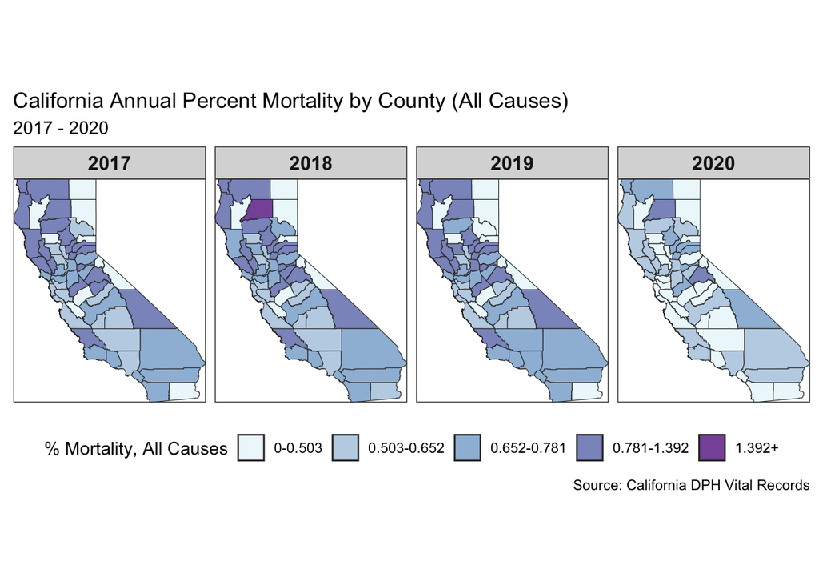

#### Question 13 [1 points]:

What patterns do you observe now, if any? Do you think this is a true pattern? Aren’t you being told that deaths are going **up** due to COVID-19??

## 2.8 The data for 2020 isn’t complete…

Ohhhh… that’s right. The pattern observed is simply a by-product of an incomplete record from 2020, isn’t it?! You only have 8 months’ of observations. You realize at this point you were so excited to jump into map-making that you missed something in how you were doing your calculations and/or planning your maps.

You decide that you had better take a look at both annual and monthly trends in the total numbers of deaths to see if that sheds some light on things:

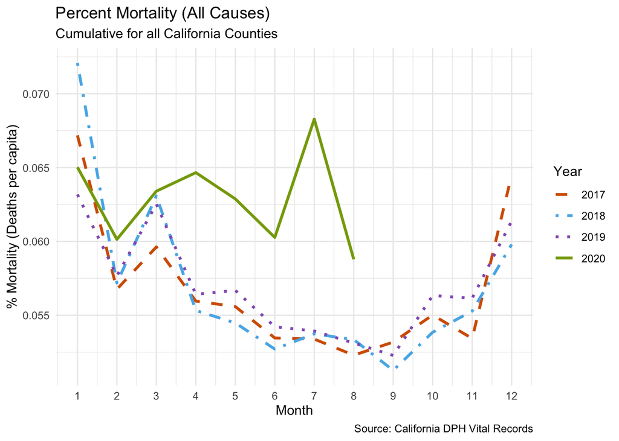

#### Question 14 [1 point]:

Why did this happen and how could you fix it? (**There is more than one correct answer possible.**) Could you have made your maps the way you did in Section 2.7 and had them be accurate if we’d had a full 12 months’ of data for each year?

**Answer:** I think 2020 only has eight months of records, which not like other years use twelve months data. There have more than one way to fix this, 1. Instead of summing whole-year totals and using monthly average of percent mortality. 2. Compare only the same months across years (for example, restrict every year to January–August) 3. Annualize the partial year by scaling the eight-month figure up to a twelve-month equivalent.

## 3.1 Fixing the map’s accuracy for 2020.

Although there are several ways you could tackle this, what I show you below is how to take an average of monthly % mortality so that it no longer matters whether you have 8 months’ or 12 months’ of data available for any given year. **NOTE** that how you accomplish this is by grouping by county, year, AND month; this way, by looking at a monthly average of percent mortality, it no longer matters whether you have an entire year’s data for 2020 or not!

```r
##### Calculate the monthly percent mortality
mortalitySummary <- mortality_sf2 %>%
  ## Group by County as well as Year
  group_by(COUNTY_NAM, Year, Month) %>%   ## <- WHERE A KEY CHANGE HAPPENS!
  ## Summarize by calculating a monthly percent mortality
  ## Note that I have to divide by the mean of the N from the Census
  ## or I'd get an error
  summarize(monthlyPercMortality = sum(totalDeaths,
                                       na.rm = TRUE)/mean(totalN)*100) %>%
  ## Ungroup - necessary to remove the grouping for future use
  ungroup() %>%
  ## NOW, you can group again by county and year and calculate the true annual
  ## average that has been adjusted for differing number of months!
  group_by(COUNTY_NAM, Year) %>%   ## <- no Month now!
  summarize(annualPercMortality = mean(monthlyPercMortality, na.rm = TRUE)*12)

#### Find the five number summary
summ <- fivenum(mortalitySummary$annualPercMortality)
paste0("The five-number summary of annual % total mortality is: ")
```

```
## [1] "The five-number summary of annual % total mortality is: "
```

```r
paste(c("Min", "Lower Quartile", "Median", "Upper Quartile", "Max"),
      round(summ, 3))
```

```
## [1] "Min 0"                "Lower Quartile 0.578" "Median 0.694"
## [4] "Upper Quartile 0.868" "Max 1.392"
```

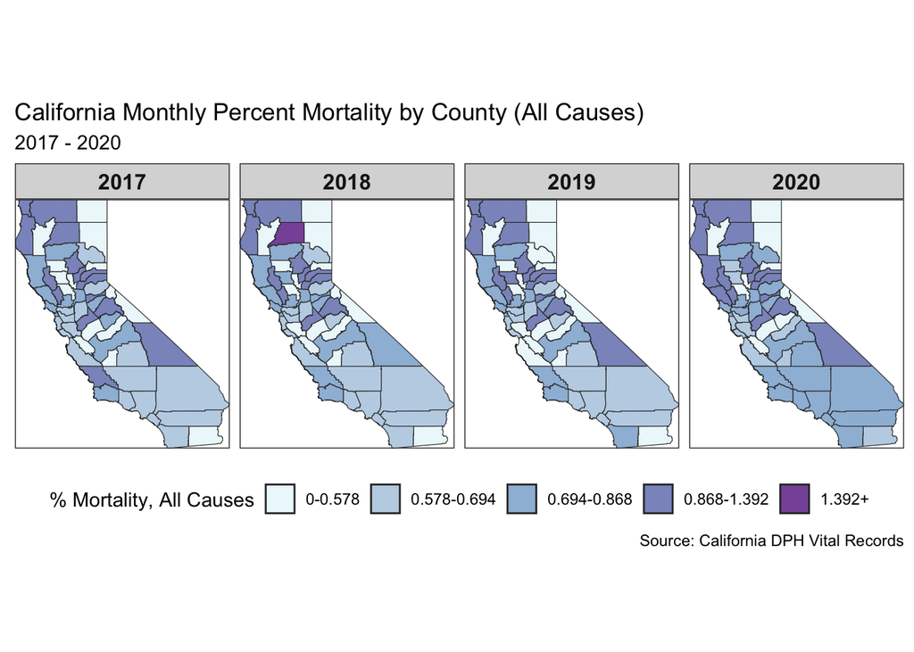

```r
##### Now add on the cuts and labels for mapping:
mortalitySummary <- mortalitySummary %>%
  mutate(deathLabels = cut(annualPercMortality,
                          breaks = c(summ, Inf),
                          labels = c("0-0.578", "0.578-0.694", "0.694-0.868",
                                    "0.868-1.392", "1.392+"),
                          ordered_result = TRUE, right = F))
```

#### Question 15 [1 points]:

**Hint**: Take a look at counties in Southern CA, like Los Angeles, Orange, San Diego, Riverside, Imperial…

**Answer:** After the monthly-average fix, 2020 is no longer the palest year — it now lines up with 2017–2019 instead of contradicting them, so the map is finally consistent with deaths rising in 2020. But the increase isn’t uniform. The Southern California counties — Los Angeles, Riverside, San Bernardino, San Diego, and especially Imperial in the far southeast — are the ones that shift into darker bins, which fits where COVID hit hardest in mid-2020 (Imperial had one of the worst outbreaks in the country). Most of the northern and rural counties look unchanged from earlier years. So it’s yes for Southern California, but not for much of the north — a regional surge rather than a statewide jump.

# 3 Project future mortality

Your stakeholders have asked if you can quickly give them *any* idea of what to expect mortality to be across the counties for the remaining months of 2020. Now, even though you knew it would not be the most robust method for time series projection available (**a caveat!**), you immediately think to yourself, “Oh, I could do a regression.” So, you do.

## 3.1 Regression predictions of mortality in 2020

First, you need to do a little prep to the data to get you started. You need to calculate the monthly percent mortality and attach it to your mortality shapefile, `mortality_sf2`.

```r
## First, calculate monthly percent mortality in your dataframe:
mortality_sf2 <- mortality_sf2 %>%
  ## Group by County as well as Year
  group_by(COUNTY_NAM, Year, Month) %>%
  ## Summarize by calculating a monthly percent mortality
  ## Note that I have to divide by the mean of the N from the Census
  ## or I'd get an error
  summarize(monthlyPercMortality = sum(totalDeaths,
                                       na.rm = TRUE)/mean(totalN)*100) %>%
  ## Ungroup - necessary to remove the grouping for future use
  ungroup()
```

Now, fit the OLS linear regression.

```r
olsModel <- lm(monthlyPercMortality ~ COUNTY_NAM + Year + Month, data = mortality_sf2)
```

Next, make some new data (stored into `newdata`) so you can generate predictions for those new data.

```r
## Make the new data:
## Get the names of the counties; repeat four times for the 4 months
COUNTY_NAM <- rep(unique(mortality_sf2$COUNTY_NAM), 4)
## Make a set of months for each of the 58 counties for Sept, Oct, Nov, Dec
Month <- c(rep(9, 58),
            rep(10, 58),
            rep(11, 58),
            rep(12, 58))
Year <- rep(2020, length(Month))
## Put this into a new dataframe called "newdata"
newdata <- cbind.data.frame(COUNTY_NAM, Year, Month)
```

Now, generate the predictions using `newdata` and attach the predicted monthly percent mortality to `newdata`. This is necessary for plotting to occur! Make sure you **check out the dimensions of the `newdata`**. Since you are missing four months’ of data (September - December) in 2020, there she be a row for every county for every month missing.

```r
## Attach it to the dataframe and then call it the same name as the original Y
newdata$percMortality <- predict(olsModel, newdata = newdata)
## Also, add a flag so that you know it is predicted
newdata$isPredicted <- "1"
```

Finally, you are ready to make a temporary dataframe, which you will call `temp`, which will pull everything together - the original data and the predictions - so that you can add them to your line graphs from above. Although I could choose to add the predictions to your mortality shapefile instead, I am choosing not to in order to keep that more pristine. I don’t want to add predictions that I may not use in the future to my good dataframe!

```r
temp <- totalDeaths %>%   ## Start from totalDeaths for simplicity
  ## Join with census by County
  full_join(census, by = "County") %>%
  ## Group by Year and then Month to aggregate the counties
  group_by(Year, Month) %>%
  ## Calculate the percent mortality - it is a percent because multiply by 100
  summarise(percMortality = sum(totalDeaths, na.rm = TRUE) /
              sum(totalN, na.rm = TRUE)*100) %>%
  ## Keep only the columns you need
  select(Year, Month, percMortality) %>%
  ## Make an empty flag column filled with zeros to flag if the data are
  ## predicted
  mutate(isPredicted = "0")

## Clean up newdata a little: you need to aggregate across the counties by year
newdata <- newdata %>%
  ## Group by Year and then Month to aggregate the counties; add isPredicted
  ## in there too so that it makes it into the final dataset!
  group_by(Year, Month, isPredicted) %>%
  ## Remove what you don't need
  select(-COUNTY_NAM) %>%
  ## Calculate a mean percent mortality
  summarize(percMortality = mean(percMortality, na.rm = TRUE))

## Row bind newdata onto temp to give you a complete, ordered, dataset for plots!
temp <- rbind(temp, newdata)
```

Lastly, finish out the year of 2020 with predictions (shown in bubble points):

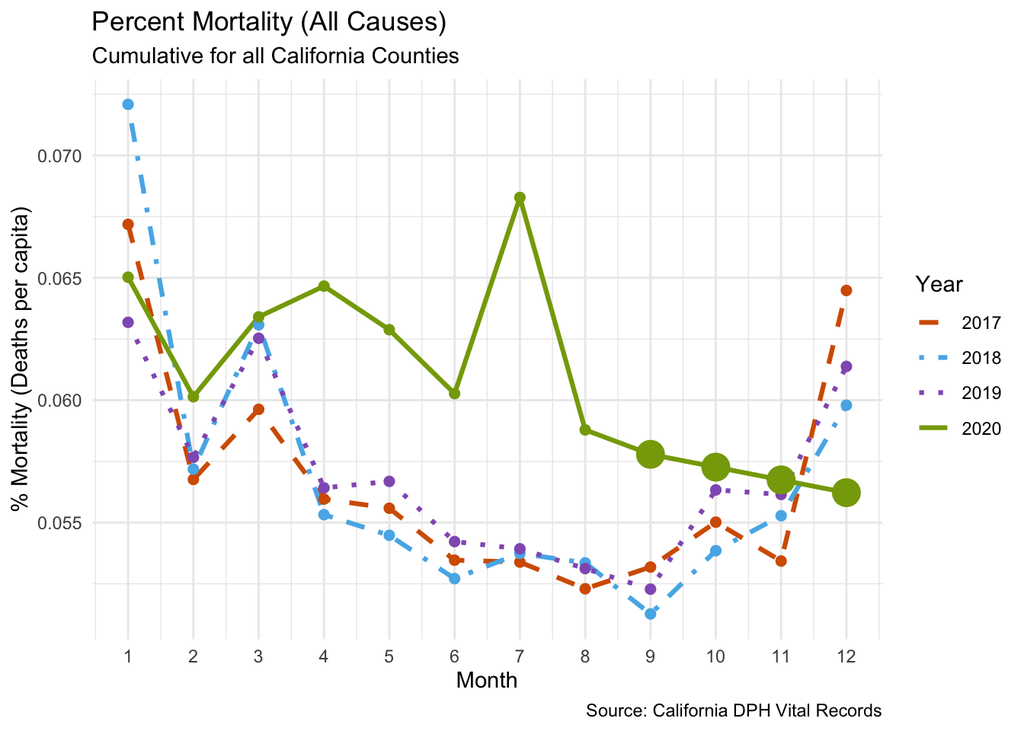

#### Question 16 [1 point]:

Do you think this regression prediction is robust? Why or why not? (**Hint**: Check your assumptions with `plot(olsModel)`!!)

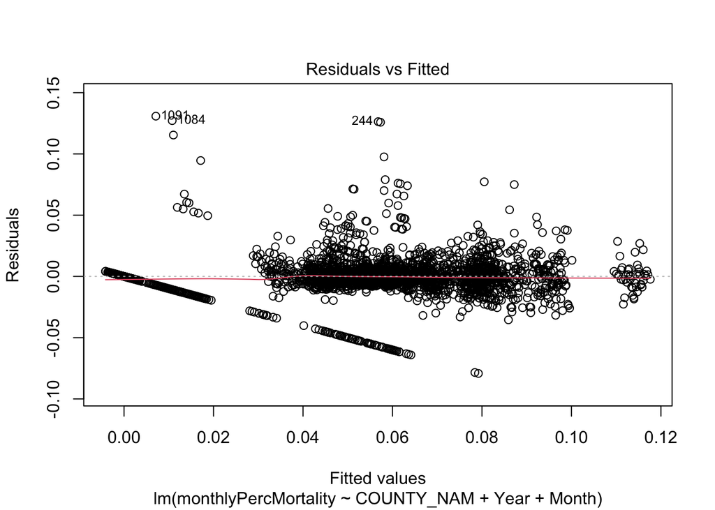

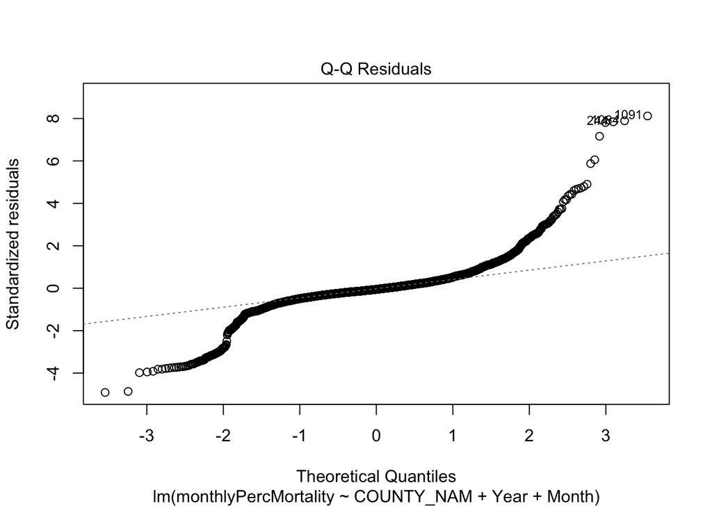

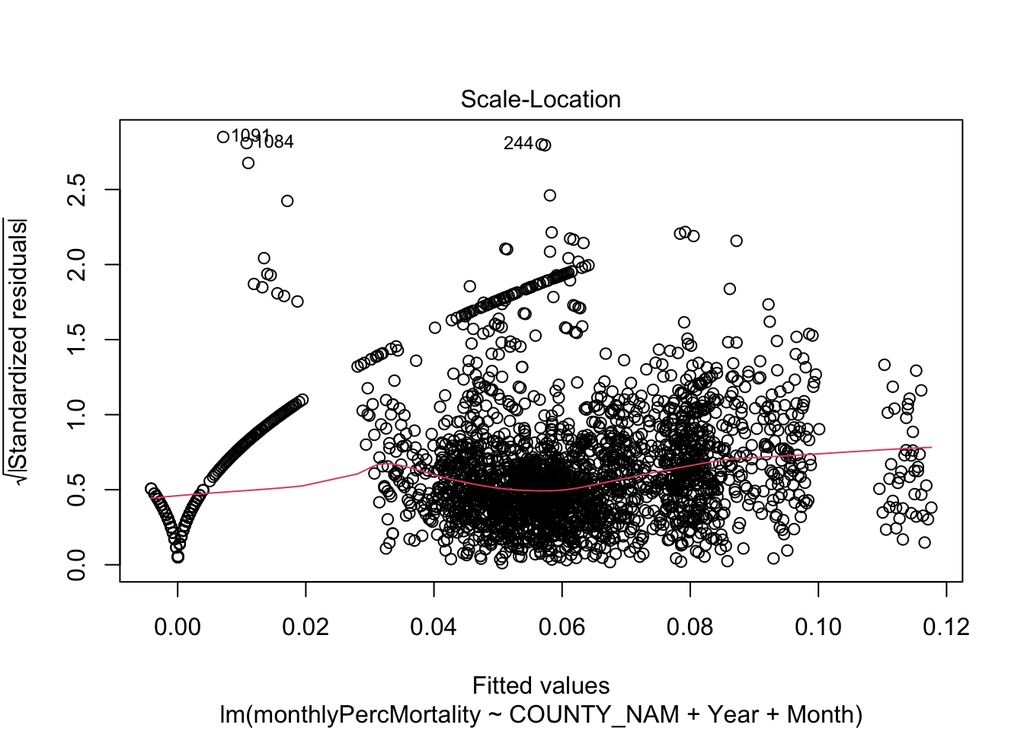

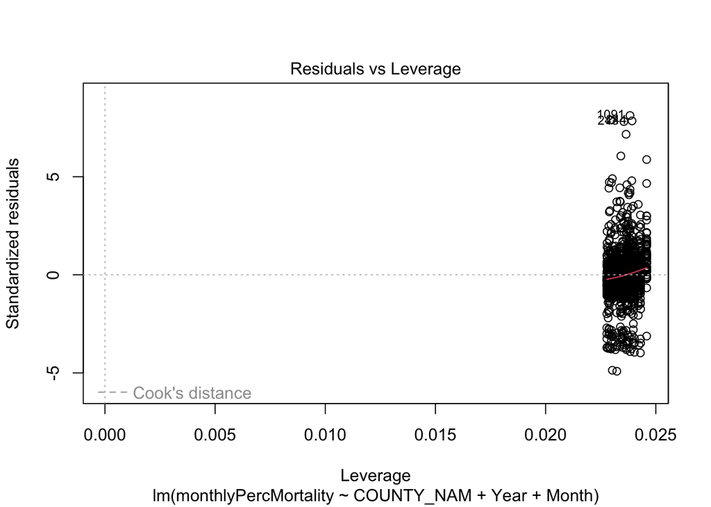

```r
plot(olsModel)
```

**Answer:** No. The diagnostic plots show the model’s errors aren’t random — they fall into clear diagonal patterns, which means it’s missing the U-shaped seasonal trend because Month was forced to be a straight line. The Q-Q plot shows a few errors as large as 8 standard deviations, which are the COVID-surge months the model badly under-predicts. The variance also isn’t constant. The only thing that looks fine is that no single data point is driving the fit, so the issue is the model’s overly simple structure, not bad data. It works as a rough first pass, but it’s not robust enough to trust as a forecast.

## 3.2 Spatial lag regression

Then you recall that class you took during your Master’s degree - what was it called again? Doesn’t matter! You remember that calculating **spatial weights** would allow you to do a type of spatial regression, such as spatial lag regression, because it deals with **spatial autocorrelation**. Right, that was the term!

### 3.2.1 Calculate spatial weights matrix

The first step in calculating a spatial weights matrix is to ensure geometry is retained in the shapefile, even if you plan to aggregate by month or by year for mapping. I actually had you covered earlier when you first calculated the monthly percent mortality, `monthlyPercMortality`, in the **mortality shapefile**, `mortality_sf2`. By ungrouping at the end of the calculation, I ensured that you lost no data or geometry! This is also exactly WHY you did not do any aggregation directly on these data or attach the subpar predictions to `mortality_sf2`.

**Warning**: Careless aggregation WILL rob you of spatial or other information, which will make spatial modeling impossible. This is because, in order to run spatial models, the spatial object *must* retain geometry.

Now that you know you have retained all of your spatial information in `mortality_sf2`, you can create the spatial weights matrix similarly to how you did it in Demo 2 using `spdep`.

1. Create neighbor list using Queen contiguity. *This could take a minute to run, be patient.*

*This identifies which counties touch each other (using `poly2nb()`). Note, however, that you are only looking at the* **unique pairs** *of county names and geometries, however, for this step.*

```r
mortality_nb <- poly2nb(mortality_sf2 %>%
                          ## Isolate the unique county name-geometry pairs
                          select(COUNTY_NAM, geometry) %>% unique() %>%
                          ## Arrange the county names alphabetically (helps
                          ## ensure no downstream issues)
                          arrange(COUNTY_NAM) %>%
                          ## Turns the county name into a factor (helps ensure
                          ## no downstream issues)
                          mutate(COUNTY_NAM = as_factor(COUNTY_NAM)),
                        snap = 500 ) # treat county borders within 500 map-units of each others as touching


## Make sure the size matches the number of counties:
length(mortality_nb)
```

```
## [1] 58
```

```r
spdep::n.comp.nb(mortality_nb)$nc   # number of sub-graphs — 1 would be correct
```

```
## [1] 1
```

#### Question 17A [0.5 points]

Why am I calculating the neighbors on just the **distinct counties** in the mortality shapefile when I just finished saying you don’t want to lose any of your spatial data for the model?

**Hint 1**: What are the dimensions of `mortality_sf2` and is it a multiple of 58?

**Hint 2**: What happens if I calculate spatial weights on redundant data? Does it cost me computationally?

2. Calculate row-standardized spatial weights matrix based on the neighbors-list. *This converts the neighbor information stored in `mortality_nb` into a usable weight list using `nb2listw()`. Neighbors have equal influence (row-standardized: `style = "W"`).*

```r
mortality_sw <- nb2listw(mortality_nb, style = "W")
```

### 3.2.2 Join spatial weights to the mortality shapefile so that every datapoint has its spatial weight.

You want to calculate, for each county in each year and month, the average percent mortality of its neighboring counties (i.e., the spatial lag). This helps you model whether mortality in one county is influenced by nearby counties. Recall from lecture and Demo 2 that a **spatial lag** is the weighted average of a variable (here, mortality) in neighboring counties. For example, if Los Angeles county is surrounded by five counties, the spatial lag for L.A. county is the average mortality rate across those five neighbors, adjusted by the spatial weights.

To accomplish this, what you need to do is loop over the time components (year and then month), and compute spatial lag for within each of the four years. you will use `purrr` to do this; it’s more computationally efficient than writing a more simple `for()` loop. As it iterates over the dataset, by year, it will use `spdep::lag.listw()` to calculate the spatial lag for each time point. The result is a new column in `mortality_sf2` that contains the average monthly mortality of any given county’s neighbors for every county-month-year combination. **Don’t forget!** You must center (not scale) the monthly percent mortality before computing the spatial weights.

```r
## Make a centered transformation of monthly percent mortality
mortality_sf2$monthlyPercMortalityCentered <- scale(mortality_sf2$monthlyPercMortality,
                                    center = TRUE, scale = FALSE)

## Initialize an empty vector to store spatial lag values
mortality_sf2$lagged_monthlyPercMortality <- NA_real_

## Calculate spatial weights for every time point
mortality_sf2 <- mortality_sf2 %>%
  arrange(COUNTY_NAM, Year, Month) %>%  ## Ensures it is in same order as weights
  ## Handles each time slice separately
  group_by(Year, Month) %>%
  mutate(
    lagged_monthlyPercMortality = {
      ## Slice to get the current group's data (i.e., one month-year combo)
      ## and then sort within group to match spatial weights
      monYr <- arrange(pick(everything()), COUNTY_NAM)$monthlyPercMortalityCentered
      ## Compute the spatial lag using the spatial weights in mortality_sw
      lag.listw(mortality_sw, monYr)
    }
  ) %>%
  ungroup()
```

### 3.2.3 Run spatial lag regression using the lagged monthly mortality as a covariate

In Demo 2, you used the `spatialreg` package’s `lagsarlm()` function to perform a spatial lag regression. However, because you needed to compute the spatial lag within each year-month combo for each county, you have to perform your spatial lag regression a little differently using just the `lm()` function and explicitly using the spatially lagged monthly percent mortality ourselves.

#### Question 17B [0.25 points]

Run a **spatial lag regression (SAR)** model using the spatial lag you just calculated. Save the model as an object called `sarModel`. I have gotten it started for you so you use the spatial lag correctly, but you need to fill in the blanks, run the analysis, and assess the results.

**Hint 1**: Your target (dependent variable) is unchanged from OLS regression.

**Hint 2**: Make sure to include both time elements as covariates!

```r
sarModel <- lm(monthlyPercMortality ~ Year + Month + lagged_monthlyPercMortality,
    data = mortality_sf2)
```

Now, let’s compare `sarModel` to `olsModel` and see which model better explains monthly percent mortality in California (uncomment to run).

```r
 anova(sarModel, olsModel)
```

```
## Analysis of Variance Table
##
## Model 1: monthlyPercMortality ~ Year + Month + lagged_monthlyPercMortality
## Model 2: monthlyPercMortality ~ COUNTY_NAM + Year + Month
##   Res.Df    RSS Df Sum of Sq      F                Pr(>F)
## 1   2548 1.9730
## 2   2492 0.6625 56    1.3105 88.029 < 0.00000000000000022 ***
## ---
## Signif. codes:  0 '***' 0.001 '**' 0.01 '*' 0.05 '.' 0.1 ' ' 1
```

#### Question 17C [0.25 points]

Which model, the spatial lag regression (`sarModel`) or the ordinary least squares regression (`olsModel`), is a better fit to the data? Why?

**Answer:** Based on above comparsion results, The OLS model (olsModel) is the better fit. its residual sum of squares is 0.663 versus 1.973 for the spatial lag model.

#### Question 17D [0.5 points]

Using the model you chose as the better model, `sarModel` to `olsModel`, interpret the results of that model. **HINT**: Remember that `summary()` helps you access the results from the model!

Make sure to interpret both the coefficients and their significance as well as the $R^2$!

```r
summary(olsModel)
```

```
##
## Call:
## lm(formula = monthlyPercMortality ~ COUNTY_NAM + Year + Month,
##     data = mortality_sf2)
##
## Residuals:
##       Min        1Q    Median        3Q       Max
## -0.079202 -0.005087 -0.000844  0.004399  0.130825
##
## Coefficients:
##                              Estimate  Std. Error t value             Pr(>|t|)
## (Intercept)               -1.53691386  0.61866160  -2.484             0.013047
## COUNTY_NAMAlpine          -0.05112698  0.00347622 -14.708 < 0.0000000000000002
## COUNTY_NAMAmador           0.02759920  0.00347622   7.939  0.00000000000000304
## COUNTY_NAMButte            0.04410694  0.00347622  12.688 < 0.0000000000000002
## COUNTY_NAMCalaveras        0.01536078  0.00347622   4.419  0.00001034859530327
## COUNTY_NAMColusa           0.00902395  0.00347622   2.596             0.009489
## COUNTY_NAMContra Costa     0.00485656  0.00347622   1.397             0.162513
## COUNTY_NAMDel Norte        0.03448020  0.00347622   9.919 < 0.0000000000000002
## COUNTY_NAMEl Dorado        0.00663477  0.00347622   1.909             0.056426
## COUNTY_NAMFresno           0.01190256  0.00347622   3.424             0.000627
## COUNTY_NAMGlenn           -0.00734965  0.00347622  -2.114             0.034591
## COUNTY_NAMHumboldt         0.02723258  0.00347622   7.834  0.00000000000000694
## COUNTY_NAMImperial        -0.00706414  0.00347622  -2.032             0.042246
## COUNTY_NAMInyo             0.02906864  0.00347622   8.362 < 0.0000000000000002
## COUNTY_NAMKern             0.00453669  0.00347622   1.305             0.191991
## COUNTY_NAMKings           -0.00538508  0.00347622  -1.549             0.121480
## COUNTY_NAMLake             0.02739469  0.00347622   7.881  0.00000000000000483
## COUNTY_NAMLassen          -0.01890745  0.00347622  -5.439  0.00000005876960477
## COUNTY_NAMLos Angeles      0.00475859  0.00347622   1.369             0.171154
## COUNTY_NAMMadera          -0.00288126  0.00347622  -0.829             0.407270
## COUNTY_NAMMarin            0.01315928  0.00347622   3.786             0.000157
## COUNTY_NAMMariposa         0.00154202  0.00347622   0.444             0.657376
## COUNTY_NAMMendocino        0.01908860  0.00347622   5.491  0.00000004396179136
## COUNTY_NAMMerced          -0.00987550  0.00347622  -2.841             0.004536
## COUNTY_NAMModoc           -0.04198383  0.00347622 -12.077 < 0.0000000000000002
## COUNTY_NAMMono            -0.05112698  0.00347622 -14.708 < 0.0000000000000002
## COUNTY_NAMMonterey        -0.00199547  0.00347622  -0.574             0.565996
## COUNTY_NAMNapa             0.02690904  0.00347622   7.741  0.00000000000001424
## COUNTY_NAMNevada           0.02985369  0.00347622   8.588 < 0.0000000000000002
```

[output cut: 83 more lines]

```
## COUNTY_NAMTehama          ***
## COUNTY_NAMTrinity         ***
## COUNTY_NAMTulare
## COUNTY_NAMTuolumne        ***
## COUNTY_NAMVentura
## COUNTY_NAMYolo            .
## COUNTY_NAMYuba            ***
## Year                      *
## Month                     ***
## ---
## Signif. codes:  0 '***' 0.001 '**' 0.01 '*' 0.05 '.' 0.1 ' ' 1
##
## Residual standard error: 0.0163 on 2492 degrees of freedom
## Multiple R-squared:  0.668,  Adjusted R-squared:  0.6602
## F-statistic:    85 on 59 and 2492 DF,  p-value: < 0.00000000000000022
```

**Answer:** In olsModel, Year is positive and significant (+0.00079, p = 0.010), while Month is negative and highly significant (−0.00052, p < 0.0001), capturing the broad seasonal decline (though as a linear term it misses the true U-shaped pattern). Most COUNTY_NAM coefficients are highly significant — Shasta is the highest (+0.063, matching the maps) and the tiny counties (Alpine, Mono, Sierra) the lowest — confirming large baseline differences between counties. The R² is 0.668 (adjusted 0.660), so the model explains about 67% of the variation, with most of the remaining unexplained variance reflecting the non-linear seasonality the linear Month term can’t capture.

#### Question 17E [0.25 points]

Can you trust the results of the model? Why or why not?

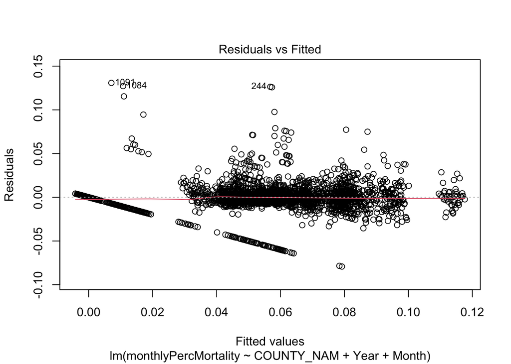

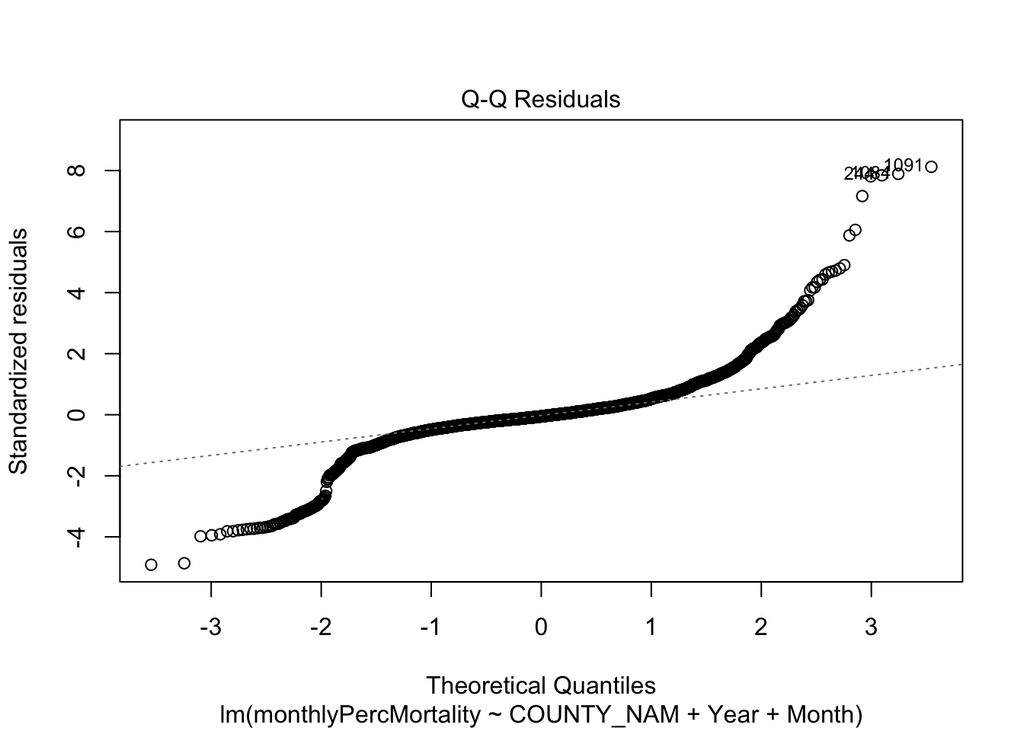

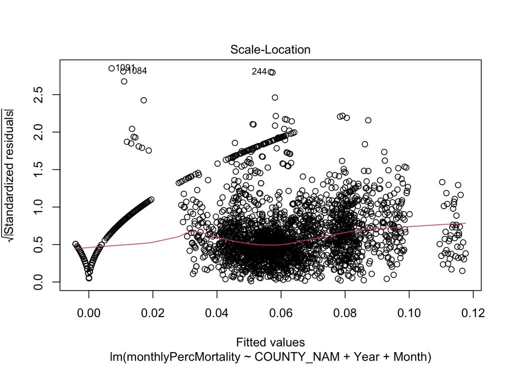

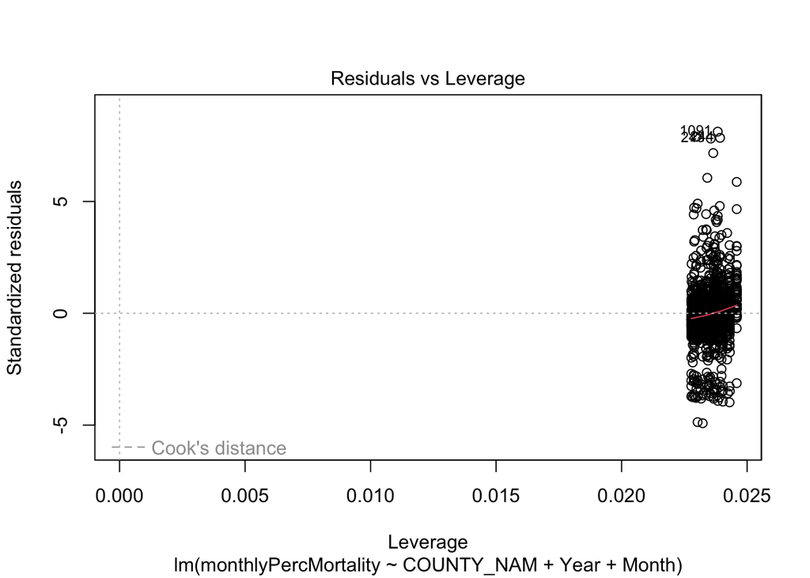

```r
plot(olsModel)
```

**Answer:** Not entirely. The diagnostic plots show the OLS assumptions are strained — the residuals aren’t normal (the Q-Q plot has a heavy right tail from the under-predicted 2020 surge), the variance isn’t constant, and the diagonal banding shows the linear Month term can’t capture the U-shaped seasonality. On top of that, this is OLS applied to spatial data, which assumes independent observations, but neighboring counties are spatially correlated — so the standard errors and p-values are likely overstated and shouldn’t be taken at face value. The model fits the data reasonably (R² = 0.67) and is useful for description, but I wouldn’t fully trust its inference or use it for forecasting.

# 4 Improve Predictions with Machine Learning

You are growing increasingly concerned that you will not be able to provide robust predictions to your stakeholder, and you’re feeling nervous - it is a new job, after all! So, you think about other ways to try to **improve the prediction**. Although you technically can’t see into the future, right now, you and I can - which is exactly what you are going to do! Unlike the random splits you have done before, you are actually going to perform what is called a **time-aware split**, where you use January 2017 to December 2019 as your training data and January to August 2020 as your testing data. This approach accounts for *temporal structure* in the data, as well as spatial structure in the data by using the lagged mortality you computed above as a spatial proxy.

*Perform a time-aware train-test split*

```r
## Make the training data
mortalityTrain <- mortality_sf2 %>%
  ## Drop the geometry to make processing downstream faster
  st_drop_geometry() %>%
  ## Filter for just the year-month combos you want
  filter(Year != 2020) %>%
  ## Drop the previously centered monthly percent mortality from when you made
  ## the spatial weights matrix
  select(-monthlyPercMortalityCentered)

## Make the testing data
mortalityTest <- mortality_sf2 %>%
  ## Drop the geometry to make processing downstream faster
  st_drop_geometry() %>%
  ## Filter for just the year-month combos you want
  filter(Year == 2020) %>%
  ## Drop the previously centered monthly percent mortality from when you made
  ## the spatial weights matrix
  select(-monthlyPercMortalityCentered)
```

#### Question 18A [0.5 points]

What percent of the data are in the training set and what percent in the testing set? You should use code to figure this out! How does it compare to the canonical 80-20 split?

```r
nTrain <- nrow(mortalityTrain)
nTest  <- nrow(mortalityTest)
total  <- nTrain + nTest

paste0("Training: ", round(100 * nTrain / total, 1), "%")
```

```
## [1] "Training: 81.8%"
```

```r
paste0("Testing:  ", round(100 * nTest  / total, 1), "%")
```

```
## [1] "Testing:  18.2%"
```

**Answer:** The training set holds about 81.8% of the data (2,088 rows — the three full years 2017–2019) and the testing set about 18.2% (464 rows — January through August 2020). That’s remarkably close to the canonical 80-20 split. What’s interesting is that this proportion wasn’t chosen — it fell out of the time-aware split, where I trained on the complete pre-2020 years and held out 2020. So even though the split was driven by time rather than a random 80-20 partition, it happens to land almost exactly on the conventional ratio.

#### Question 18B [0.5 points]

What caveats or limitations can you think of by using none of the 2020 data in the training set?

**Answer:** 2017–2019 are pre-pandemic years, while 2020 was a structural break — COVID and the shutdown made it a completely different regime. Since the model was trained without any 2020 data, it has no way to anticipate the surge and will likely under-predict it. And because the test set (2020) is so different from the training years, a poor test score may reflect that 2020 was anomalous rather than that the model itself is bad.

On top of that, 2020 is outside the training range, and a random forest can’t predict values beyond what it saw in training — so it’s structurally pushed toward under-prediction for a high-mortality year.

## 4.1 Fitting an out-of-bag (OOB) random forest (RF) model

You decide to use random forest (RF) for this task because it handles non-linearity, which you know you have from your time plots above AND from the summaries of both your OLS and SAR regressions. You also choose to use RF because it can be more robust to outliers and still give some idea of importance for interpretability for your stakeholders. Your basic workflow will be to:

1. Center and scale the predictors
2. Fit the model with OOB error
3. Fit the model with 10-fold cross-validation
4. Compare the RMSE of the two models
5. Show the variable importance of the final model

You decide to leverage the `caret` package in R again for much of your model fitting and tuning needs. If you want to know more about what `caret` does and doesn’t do, this [chapter](https://daviddalpiaz.github.io/r4sl/the-caret-package.html) can help.

#### Question 19A [0.5 points]

What does it mean to “fit a model with out-of-bag (OOB) error”? Why do we do it? What can it tell you here?

**Answer:** Out-of-bag error works because each tree in a random forest is trained on a bootstrap sample that randomly leaves out about a third of the data. OOB error predicts each observation using only the trees that didn’t see it, so it gives a built-in estimate of how the model generalizes to new data — for free, without needing a separate validation set or cross-validation. Here it gives me a quick read on how well the model fits the 2017–2019 data before I run the formal 10-fold CV, though it only reflects performance within those pre-2020 years, not the unusual 2020 test set.

Even though you have no encoding, you know that you need to center and scale your data before running the random forest! So, you decide to leverage the `preProcess()` function in the `caret` package to help you center and scale the predictors. You perform the preprocessing explicitly here, storing the pre-processed training *instructions* in `preProcInstructions`. Then, you can apply the pre-processing to the training data, `mortalityTrain`, using the `predict()` function. Note that this is a different step than when you are predicting from a model for performance evaluation!

```r
## First, make a new object, preProcInstructions, that stores the
## pre-processing instructions from mortalityTrain:
preProcInstructions <- preProcess(mortalityTrain,
                                    method = c("center", "scale"))

## Now apply the pre-processing instructions using predict()
mortalityTrain <- predict(preProcInstructions,
                                      newdata = mortalityTrain)
```

Then, you fit the OOB RF model after using the `trainControl()` function to tell it to fit the training model with OOB error.

*Fit an OOB random forest (RF) model*

```r
## Define training control for OOB
ctrlOOB <- trainControl(method = "oob")

## Define the tuning grid
tuneGrid <- expand.grid(mtry = 1:3)  ## Coerce it to use mtry 1 through 3

## Run the OOB random forest, including preprocessing instructions
rfOOB <- train(
  ## Define the model - everything but COUNTY_NAM
  monthlyPercMortality ~ Year + Month + lagged_monthlyPercMortality,
  ## Set the data
  data = mortalityTrain,
  ## Indicate that it is a random forest
  method = "rf",
  ## Indicate the training control method to use, defined above
  trControl = ctrlOOB,
  ## Indicate that you want to extract importance at the end
  importance = TRUE,
  ## Indicate the tuning grid, defined explicitly above
  tuneGrid = tuneGrid
)
```

Note that here you coerce it to use an `mtry` hyperparameter grid search of 1 through 3. This is just because you have a really non-complex dataset (only 3 predictors!) and you want to force it to run *as if* it had a little more complexity. Why? Just to make sure it searches long enough!

#### Question 19B [0.5 points]

What is `mtry` and what is it doing in the context of a random forest? What is the default `mtry` for a random forest regression? Why am I choosing to override it here, do you think?

*Look at the results ($RMSE$ and $R^2$) of the OOB random forest*

```r
rfOOB$results %>%
  kable(
    format = "html",
    caption = "Table 3. Results of the OOB random forest on California Mortality (All Causes).") %>%
    kable_styling(bootstrap_options = c("hover"))
```

Table 3. Results of the OOB random forest on California Mortality (All Causes).

| RMSE | Rsquared | mtry |
| --- | --- | --- |
| 0.9865418 | 0.0262690 | 1 |
| 1.0371548 | -0.0762055 | 2 |
| 1.0631608 | -0.1308526 | 3 |

Recall from the Elastic Net you fitted a couple weeks ago on the hospital readmissions data that you optimized a hyperparameter, $\lambda$, to get the best-tuned model. It is the same idea here with `mtry`. Remember, optimized results will be the **lowest error** as measured by Root Mean-Squared Error ($RMSE$) and the highest percent of the variance in the target explained, $R^2$. In other words, you want a model that uses as much information as it can, which results in lower error, and betters your chances that it will return a good prediction!

#### Question 19C [0.5 points]

Which value of `mtry` gave the best results? (**Hint**: Can $R^2$ values be negative?!?). Are you able to compare the $RMSE$ of this model to the one you fitted in Question 16C? Why or why not? (**Hint**: Does your pre-processing step apply to the target too? You may have to do a little research!)

**Answer:** Which mtry: mtry = 1. It has the lowest RMSE (0.986) and the highest R² — and it’s the only one of the three that’s positive. The hint is nudging you toward the fact that R² can be negative here: mtry = 2 and 3 come out negative, which means those models predict worse than just using the mean of the outcome. So mtry = 1 isn’t just the relative winner, it’s the only one doing anything at all.

the RMSEs aren’t comparable because the preprocessing standardized the outcome, putting this model’s RMSE in different (SD) units than 16C’s raw-scale RMSE. In Question 16C model was fit on the raw monthlyPercMortality

## 4.2 Fitting a 10-fold cross-validated random forest (RF) model

You now feel decide to move forward with the 10-fold cross-validation. Remember that this is to **help control for overfitting**, which you can identify by looking at the error ($RMSE$) and fit ($R^2$) in each of the folds.

*Define the training control method as 10-fold cross-validation (CV) and run the model*

```r
## Define training control for 10-fold cross-validation
ctrlCV <- trainControl(method = "cv", number = 10)

## Run the 10-fold CV random forest, including preprocessing instructions
rfCV <- train(
  ## Define the model
  monthlyPercMortality ~ Year + Month + lagged_monthlyPercMortality,
  ## Set the data
  data = mortalityTrain,
  ## Indicate that it is a random forest
  method = "rf",
  ## Indicate the training control method to use, defined above
  trControl = ctrlCV,
  ## Indicate that you want to extract importance at the end
  importance = TRUE,
  ## Indicate the tuning grid, defined explicitly earlier
  tuneGrid = tuneGrid
)
```

*Look at the results ($RMSE$ and $R^2$) of the OOB random forest*

```r
rfCV$results %>%
  kable(
    format = "html",
    caption = "Table 4. Results of the 10-fold CV random forest on California Mortality (All Causes).") %>%
    kable_styling(bootstrap_options = c("hover"))
```

Table 4. Results of the 10-fold CV random forest on California Mortality (All Causes).

| mtry | RMSE | Rsquared | MAE | RMSESD | RsquaredSD | MAESD |
| --- | --- | --- | --- | --- | --- | --- |
| 1 | 0.987385 | 0.0338536 | 0.7010956 | 0.0535560 | 0.0336621 | 0.0325538 |
| 2 | 1.043853 | 0.0162454 | 0.7653652 | 0.0543191 | 0.0187963 | 0.0397577 |
| 3 | 1.070201 | 0.0129628 | 0.7911923 | 0.0522624 | 0.0150791 | 0.0393181 |

#### Question 19D [0.5 points]

What do you notice about the effects of cross-validation on your model? (**Hint**: Do you see any negative $R^2$ values this time?) Which value of `mtry` gave the best results? How does the $RMSE$ of that model compare to the one you chose as the optimal OOB model?

## 4.3 Test the training model with the 2020 data

### 4.3.1 Preprocess your test data with the same centering/scaling

Since you used `caret`’s `preProcess()` during model training, then you also have to apply the same transformation to your testing data for predictions!

Notice that you will *first* store the pre-processed values for the training set in its own object, `preProcInstructions`, and then you apply the same pre-processing on the training set using the `predict()` function. This is **separate** from the predictions you will make on the testing set using the model!

```r
## Apply the same preprocessing as training using predict(),
## using the test data
mortalityTest <- predict(preProcInstructions, newdata = mortalityTest)
```

### 4.3.2 Predict using the best RF model

An advantage of using `caret` is that it will automatically identify your best model for us, which you can access by simply using the model object `rfCV` with `predict()`. **Make sure you think about why you are using `rfCV` and not `rfOOB` here!**

```r
## Predict on pre-processed test data using the best trained RF model
rfPredictions <- predict(rfCV, newdata = mortalityTest)
```

### 4.3.3 Evaluate performance with $RMSE$ and $MAE$

`caret` also has built-in functions to calculate key performance metrics, like $RMSE$ and $MAE$ for regression models or a confusion matrix with accuracy for classification models. You can read more about them in this [chapter](https://topepo.github.io/caret/measuring-performance.html).

```r
### Compute RMSE (Root Mean Squared Error)
rfRMSE <- RMSE(pred = rfPredictions, obs = mortalityTest$monthlyPercMortality)

## Compute MAE (Mean Absolute Error) as well, optionally
rfMAE <- MAE(pred = rfPredictions, obs = mortalityTest$monthlyPercMortality)

## Print results
print(paste0("Random Forest Test RMSE:   ", round(rfRMSE, 4)))
```

```
## [1] "Random Forest Test RMSE:   0.986"
```

```r
print(paste0("Random Forest Test MAE:    ", round(rfMAE, 4)))
```

```
## [1] "Random Forest Test MAE:    0.7167"
```

#### Question 19E [0.5 points]

Can you interpret the $RMSE$ and $MAE$ values? **Remember** all of the data were subject to pre-processing, both target and predictors!

**How did the training model perform?** Does it seem to be overfitting (training error >> testing error), underfitting (training error and testing error both high but roughly equal with a low $R^2$), or doing okay?

### 4.3.4 Plot Actual vs. Predicted Values

Unimpressed with the results so far, you decide to plot the actual vs. predicted values because that can tell you whether your training model is likely leading to an **under prediction** or an **over prediction** relative to the true values of mortality. Using the `ggExtra` package, you add histograms to the margins of the scatterplot as well to help you interpret correctly.

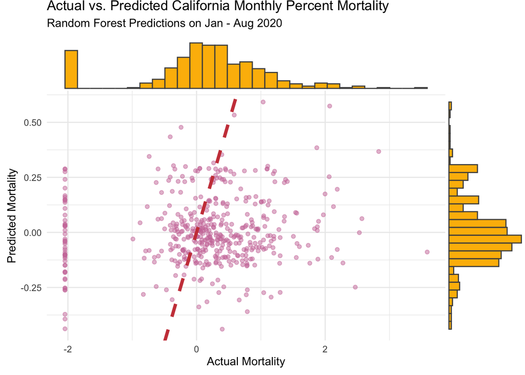

```r
## Make a scatterplot of the actual vs. predicted values
p <- ggplot(mortalityTest, aes(x = monthlyPercMortality, y = rfPredictions)) +
  ## Scatteplot with geom_point
  geom_point(alpha = 0.5, color = skittles[4]) +
  ## Add a line to help see the general trend
  geom_abline(color = skittles[3], linetype = "dashed", size = 1.5) +
  theme_minimal() +
  labs(
    title = "Actual vs. Predicted California Monthly Percent Mortality",
    subtitle = "Random Forest Predictions on Jan - Aug 2020",
    x = "Actual Mortality",
    y = "Predicted Mortality"
  )
## Add marginal histograms with the ggExtra package
ggMarginal(p, type = "histogram", fill = skittles[2], color = "gray30")
```

#### Question 19F [0.5 points]

Interpret the scatterplot of the actual vs. predicted values. What is happening to the predicted values? (Use the histogram on the side to help you, that’s why they’re there!) Make sure to mention whether the training model is leading to an **under prediction** or an **over prediction** of mortality. What **real information** might that provide your stakeholders, even if the model is underperforming?

**Answer:** The predicted values are squished into a narrow band around zero, while the actual values spread much wider — you can see it in the histograms: the predictions (right) are tight and centered near zero, but the actuals (top) have a long right tail the model never reaches. Because high actual values get predicted far too low, the model is under-predicting — it guesses lower than what actually happened. That makes sense, since the random forest only trained on 2017–2019 and can’t extrapolate to 2020’s elevated mortality, so it pulls everything back toward the normal-year average.

## 4.4 Extract variable importance from the final model

You also decide to extract the variable importance from the final trained model to share with your stakeholders.

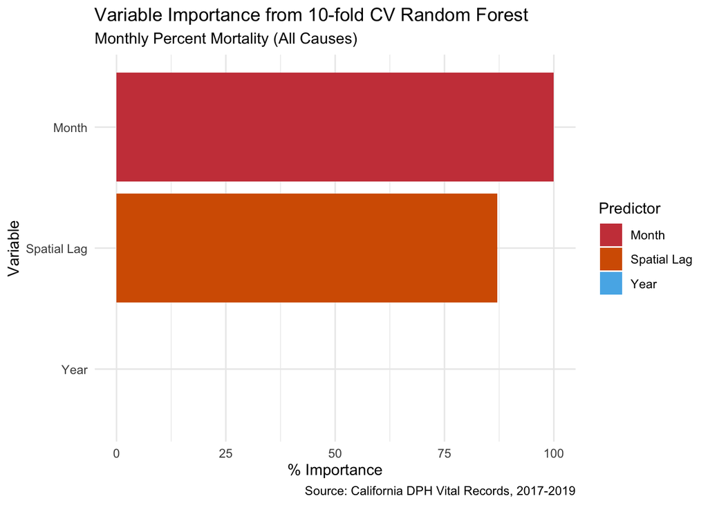

Table 5. Results of the 10-fold CV random forest on California Mortality (All Causes).

|  | Overall |
| --- | --- |
| Year | 0.00 |
| Month | 100.00 |
| lagged_monthlyPercMortality | 87.07 |

## 4.5 Comparing your predictions to the real deaths data

Now, let’s pretend that you’re skipping ahead a few months in time and you’re actually able to assess just how well your prediction could do in reality. While what you *could* do is fit a 10-fold, cross-validated random forest on all of the data and download the remaining months of 2020 and use all of 2020 as your test dataset, instead I’m just going to ask you to do a simple correlation to see how badly - or well - it did in reality.

#### Question 19G [5 points]

Since the pandemic is over in reality, you can find the actual number of deaths, per county, [here](https://data.chhs.ca.gov/dataset/death-profiles-by-county/resource/579cc04a-52d6-4c4c-b2df-ad901c9049b7).

**Hint**: You can read this file in as a dataframe using an API and `fromJSON()` as follows! Note the structure of the data - it returns a list of a list, so in order to extract the data as a dataframe we have to go two layers deep. I also show you the structure (`str()`) of the data so you have an idea what you’re getting.

```r
filters <- '{"Year":"2020","Cause":"ALL","Strata":"Total Population","Geography_Type":"Occurrence"}'
url <- paste0("https://data.chhs.ca.gov/api/3/action/datastore_search",
              "?resource_id=078185a9-e3a7-403f-a546-b8c582f0a9d8",
              "&limit=10000",
              "&filters=", URLencode(filters, reserved = TRUE))

caliDeaths <- fromJSON(url)

#nrow(caliDeaths)              # expect ~696 (58 counties × 12 months of 2020)
#unique(caliDeaths$Year)       # should be just "2020"

#caliDeaths <- fromJSON("https://data.chhs.ca.gov/api/3/action/datastore_search?resource_id=078185a9-e3a7-403f-a546-b8c582f0a9d8&limit=10000")



caliDeaths <- caliDeaths$result$records

caliDeaths %>%
  str()
```

```
## 'data.frame':    696 obs. of  14 variables:
##  $ _id               : int  126673 126855 127037 127219 127401 127583 127765 127947 128129 128311 ...
##  $ Year              : chr  "2020" "2020" "2020" "2020" ...
##  $ Month             : chr  "01" "01" "01" "01" ...
##  $ County            : chr  "Alameda" "Alpine" "Amador" "Butte" ...
##  $ Geography_Type    : chr  "Occurrence" "Occurrence" "Occurrence" "Occurrence" ...
##  $ Strata            : chr  "Total Population" "Total Population" "Total Population" "Total Population" ...
##  $ Strata_Name       : chr  "Total Population" "Total Population" "Total Population" "Total Population" ...
##  $ Cause             : chr  "ALL" "ALL" "ALL" "ALL" ...
##  $ Cause_Desc        : chr  "All causes (total)" "All causes (total)" "All causes (total)" "All causes (total)" ...
##  $ ICD_Revision      : chr  "ICD-10" "ICD-10" "ICD-10" "ICD-10" ...
##  $ Count             : chr  "973" NA "37" "162" ...
##  $ Annotation_Code   : chr  NA "1" NA NA ...
##  $ Annotation_Desc   : chr  NA "Cell suppressed for small numbers" NA NA ...
##  $ Data_Revision_Date: chr  "12/20/2024" "12/20/2024" "12/20/2024" "12/20/2024" ...
```

```r
## Alternatively, load from Rdata:
# source("caliDeaths.Rdata")
```

**Remember** to filter for the proper condition, Year, and Months to get the data you need. Take time to explore the data, and make sure that you are matching the data we’ve been using (total mortality, all causes of death) to your filter.

```r
realDeaths <- caliDeaths %>%
  filter(Cause == "ALL",
         Strata == "Total Population",
         Geography_Type == "Occurrence",     # match your totalDeaths convention (see note)
         Year == "2020",
         Month %in% c("09", "10", "11", "12")) %>%   # character, zero-padded!
  mutate(Year   = as.numeric(Year),
         Month  = as.numeric(Month),
         deaths = as.numeric(Count)) %>%
  left_join(census, by = "County") %>%
  mutate(realMonthlyPercMortality = deaths / totalN * 100) %>%
  select(County, Year, Month, realMonthlyPercMortality)

## Sanity checks
nrow(realDeaths)              ## expect ~58 counties × 4 months ≈ 232 (minus any suppressed)
```

```
## [1] 232
```

```r
unique(realDeaths$County)     ## should be CA counties
```

```
##  [1] "Alameda"         "Alpine"          "Amador"          "Butte"
##  [5] "Calaveras"       "Colusa"          "Contra Costa"    "Del Norte"
##  [9] "El Dorado"       "Fresno"          "Glenn"           "Humboldt"
## [13] "Imperial"        "Inyo"            "Kern"            "Kings"
## [17] "Lake"            "Lassen"          "Los Angeles"     "Madera"
## [21] "Marin"           "Mariposa"        "Mendocino"       "Merced"
## [25] "Modoc"           "Mono"            "Monterey"        "Napa"
## [29] "Nevada"          "Orange"          "Placer"          "Plumas"
## [33] "Riverside"       "Sacramento"      "San Benito"      "San Bernardino"
## [37] "San Diego"       "San Francisco"   "San Joaquin"     "San Luis Obispo"
## [41] "San Mateo"       "Santa Barbara"   "Santa Clara"     "Santa Cruz"
## [45] "Shasta"          "Sierra"          "Siskiyou"        "Solano"
## [49] "Sonoma"          "Stanislaus"      "Sutter"          "Tehama"
## [53] "Trinity"         "Tulare"          "Tuolumne"        "Ventura"
## [57] "Yolo"            "Yuba"
```

Now make sure to compute the **monthly percent mortality** as you have done before. Otherwise, you won’t be comparing apples-to-apples!

```r
## Done in above code
```

Lastly, create (1) a scatterplot with trend line and (2) perform a correlation test on your **Sept to December 2020** predictions relative to the true **Sept to December 2020** monthly percent mortality.

```r
## Per-county Sept–Dec 2020 OLS predictions
predGrid <- expand.grid(
  COUNTY_NAM = unique(mortality_sf2$COUNTY_NAM),
  Month      = 9:12,
  Year       = 2020
)
predGrid$predMonthlyPercMortality <- predict(olsModel, newdata = predGrid)

## Join predictions to the real Sept–Dec 2020 values
compareDF <- predGrid %>%
  rename(County = COUNTY_NAM) %>%
  left_join(realDeaths, by = c("County", "Year", "Month")) %>%
  filter(!is.na(realMonthlyPercMortality))

nrow(compareDF)
```

```
## [1] 214
```

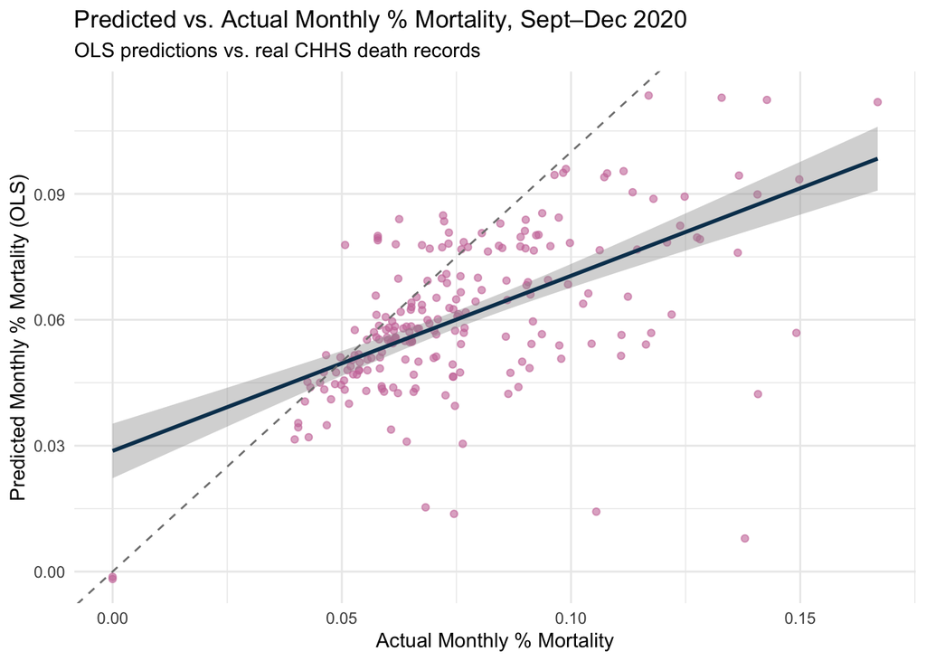

```r
## Scatterplot with trend line
ggplot(compareDF, aes(x = realMonthlyPercMortality, y = predMonthlyPercMortality)) +
  geom_point(alpha = 0.6, color = skittles[4]) +
  geom_smooth(method = "lm", color = skittles[8]) +                    # trend line
  geom_abline(slope = 1, intercept = 0, linetype = "dashed",          # perfect-prediction reference
              color = "gray50") +
  labs(title = "Predicted vs. Actual Monthly % Mortality, Sept–Dec 2020",
       subtitle = "OLS predictions vs. real CHHS death records",
       x = "Actual Monthly % Mortality",
       y = "Predicted Monthly % Mortality (OLS)") +
  theme_minimal()
```

```r
## Correlation test
cor.test(compareDF$predMonthlyPercMortality, compareDF$realMonthlyPercMortality)
```

```
##
##  Pearson's product-moment correlation
##
## data:  compareDF$predMonthlyPercMortality and compareDF$realMonthlyPercMortality
## t = 10.195, df = 212, p-value < 0.00000000000000022
## alternative hypothesis: true correlation is not equal to 0
## 95 percent confidence interval:
##  0.4760878 0.6571452
## sample estimates:
##       cor
## 0.5735806
```

**For full credit** include a brief interpretation of your findings.

#### Question 19H [1 point]

By now, it should be clear that there is a **monthly seasonality** to deaths that has nothing to do with what year it is, even though 2020 was a pandemic year. In fact, that seasonality is so strong that it ends up as a very strong predictor - about as strong as the spatial autocorrelation! Although I wish I could dive into that with you deeply now, I would not be able to do the topic justice. Note that Merrimack offers an entire course on time series - but if you are unable to take the course but want to learn more on your own, one resource I can recommend is [A Little Book of R For Time Series by Avril Coghlan](https://app.readthedocs.org/projects/a-little-book-of-r-for-time-series/downloads/pdf/latest/).

Since you can’t go deeply into doing it, instead you will do a little reading/research. I suggest reading about *temporal autocorrelation* or *seasonal momentum* and how adding time-series lags can help. How might time series lags capture what the “Month” variable alone may not fully capture, in a similar way to how “County” alone may not fully capture spatial relationships?

**Note**: Doing the time-aware data partition into before 2020 and after 2020 IS a form of controlling for temporal patterns/seasonality, albeit not as robust as including temporally lagged variables.

**Answer:** The Month variable captures the recurring seasonal level for each calendar month — the part of the pattern that repeats every year — but it treats each month as a fixed, independent value with no memory of what came right before it. A time-series lag adds that memory by using recent values (last month’s mortality, or a rolling average of the last few months) as predictors. This captures temporal autocorrelation: the well-documented fact that observations close together in time tend to be close in value, so a series carries momentum from one period to the next.

This is the direct time-analog of the spatial side. County alone gives each county a fixed baseline but ignores that counties influence their neighbors — the spatial lag fixes that by averaging neighboring counties’ values. In the same way, Month alone gives each month a fixed seasonal baseline but ignores that a month sits inside a trajectory — a temporal lag fixes that by borrowing from recent time points. Both lags model the same underlying idea: nearby observations, whether nearby in space or in time, are correlated, so a neighbor’s (or a recent period’s) value is informative beyond what a static label can encode. Concretely, in 2020 the Month term alone would predict a normal October, but a temporal lag would carry the already-elevated August–September surge forward and predict an elevated October too.

#### Question 19I [1 point]

**Would you like to see how I got this?** This source code contains all of the steps of analysis, with comments, and will show you these same results! Make sure to open the source code if you want to see the step-by-step instructions and not just the output! In brief, what I do is engineer temporal lag and rolling means features to inform the model how the target behaved in the past. Lags are explicitly accounting for temporal autocorrelation; rolling averages show recent trends and smooth noise. Then, I do the time-aware split again using the 2020 data as my holdout testing set. I then add the lagged and rolling means features, along with the spatial lag, month, and year variables as predictors to the RF model and assess performance on the testing holdout set. Note that RF is a particularly good choice for temporal models because it is non-linear; further, adding lags makes it partially time-aware. **However, don’t forget to ALWAYS validate with time held out, not random sampling, in temporal models!**

```r
source("mortalityTemporalLagRF.R")
```

```
## [1] "These are the results of a temporally lagged 10-CV random forest."
## [1] "These are the training performance metrics:"
##   mtry      RMSE  Rsquared       MAE     RMSESD RsquaredSD      MAESD
## 1    2 0.4029769 0.8396583 0.2079232 0.06192492 0.03669966 0.02498881
## 2    5 0.3181286 0.9009219 0.1610323 0.05213662 0.02404050 0.01892635
## 3    8 0.2633506 0.9321109 0.1353504 0.04032192 0.01737609 0.01421304
## [1] "These are the testing performance metrics using the 2020 holdout set:"
## [1] "Random Forest Test RMSE:   0.2491"
## [1] "Random Forest Test MAE:    0.1293"
```

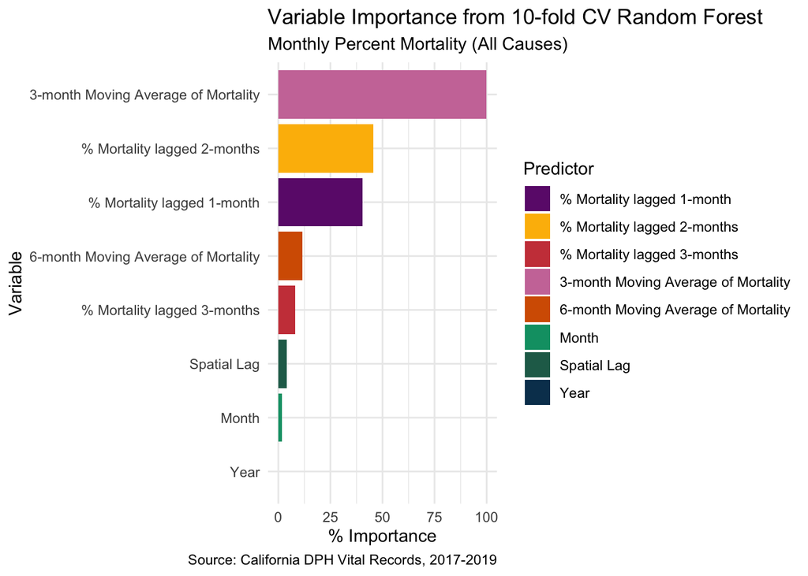

#### Question 19J [1 point]

What is something **else** you can do to improve your model that you have not discussed or explored at all here? **Hint**: Random forest models need complexity!

**Answer:** Something I could consider here is adding more predictor variables - Right now the model only sees Year, Month, the spatial lag, and the temporal lags/rolling means, which is a fairly thin set of features, and random forests do better with more complexity to split on. The most obvious addition is the Census demographics, especially the percent of the population over 65, which is one of the strongest known drivers of mortality, along with the sex ratio, the retiree ratio, and population size.

#### Question 19K [3 points]

Take all of the findings and interpretations from questions 18A-J and write up a short paragraph or two summary for your stakeholders. Your writing should not be overly technical but it should include caveats and limitations. Make sure to include 1-2 sentences of recommendations about what you would do next.

**Answer:**

We built models to predict monthly mortality across California’s counties, training them on 2017–2019 data and testing how well they would have predicted 2020. Our early models, which relied mainly on the time of year and where a county is located. They consistently predicted fewer deaths than actually occurred, because they had only ever seen normal, pre-pandemic years and had no way to anticipate the COVID-19 surge. When we compared the predictions against the real late 2020 death records, they were only moderately accurate: the model correctly identified which counties tend to run higher or lower, but it underestimated the hardest-hit months.

The model improved dramatically once we provide extra features related with mortality, information about how many deaths had occurred in the preceding months. Recent trends turned out to be the single most powerful predictor, more than either season or geography, and the improved model tracked 2020 far more accurately and performed consistently on data it hadn’t seen before. Still, two limitations matter: no model can foresee an unprecedented event like a pandemic it has never observed, so predictions become unreliable whenever conditions break sharply from the past; and estimates are weaker for very small counties, where deaths are sparse or withheld for privacy. Going forward, we recommend enriching the model with information we already have — especially each county’s share of residents over 65, a strong driver of mortality and continuing to update it with recent data so it can adapt as conditions change.

# 5 Zooming in on Mortality Causes

California was one of the strictest states when it came to shutdown measures during the COVID-19 pandemic, with both statewide enforcement and a duration longer than some other states in the country. California declared a state of emergency on **March 4, 2020** with a a mandatory statewide stay-at-home order issued on **March 19, 2020**. This statewide order didn’t end until **January 25, 2021**, but it still wouldn’t be until April 6, 2021 when the state announced plans to fully reopen the economy by **June 15, 2021**.

Your stakeholder is actually not as interested in deaths from COVID-19, but actually more interested in how the mandatory stay-at-home order seems to affecting mortality due to certain conditions. **For example, are people less likely to die from accident or injury since they’re under stay-at-home orders?**

## 5.1 Death from Accident & Injury

Because of the mandatory COVID-19 shutdown in California, which has led to generally reduced movement throughout California, your stakeholder would like to know if the number of accidental deaths declined enough **during COVID-19 shutdown** to generate a signal.

**HYPOTHESIS**: You hypothesize that because of intense, mandatory stay-at-home measures, deaths attributed to accidents and injuries (`INJ`) declined during the COVID-19 shutdown during the months of 2020 in California.

You will start, as with all good analysis plans, with some more **Exploratory Data Analysis**.

### 5.1.1 Sex-specific Effects on `INJ` Mortality

#### 5.1.1.1 Total Deaths by Sex

Your stakeholder asks you to be sure to **stratify by the sex of the decedent**, because they suspect there is a difference in death rates by the decedent’s biological sex.

The leading causes of death are located in the `sexDeaths` table because that was how the data were provided to you. They are separated by sex, thus you can check to see if there are sex differences that could matter for your analysis. You need to join some of your tables and calculate some additional metrics as well, including:

- Proportion of deaths from accident or injury out of all deaths (no longer adjusting for population size)
- Ratio of adult females to males in the population
- Ratio of females to males in the population among those over 65 years of age
- Ratio of all adults over the age of 65 (retirement age) to those under retirement age

You have opted to adjust per total deaths, rather than population size, so that you can better examine the fraction of deaths due to particular causes regardless of the underlying size of the population. However, you need to account for the ratio of females to males in the population, as it might be useful now or in future analyses to have access to the ratio of females to males. Similarly, having the ratio of retirees in the population (those over the age of 65 year) relative to non-retirees in the population may also be useful in future analyses. Further, the size of a county may still matter; so you will likely want to retain the total sample size of the county as a control variable as well. Note that, in a more detailed analysis, **population density** would be better than population size, but this is the proxy of county size you currently have to work with!

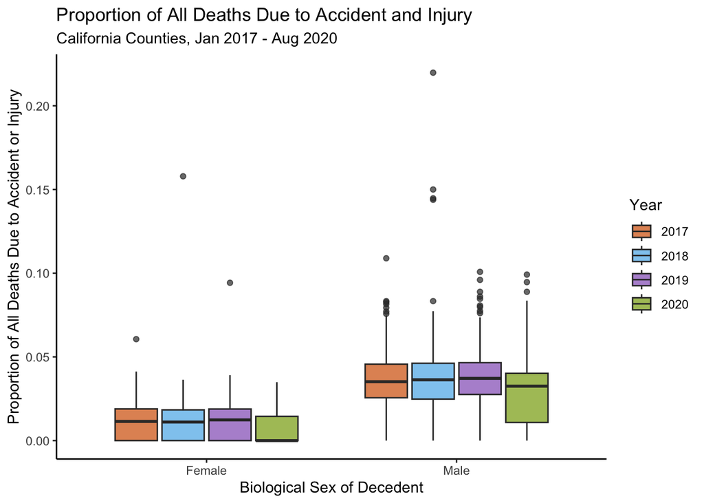

```r
## Join the sex deaths table with the census data; then filter for INJ
injDeaths <- sexDeaths %>%
  full_join(census, by = "County") %>%
  ## Here is where you filter for a specific cause of death relative to sex
  filter(leadingCauseDeath == "INJ") %>%
  ## Now full join with the first 4 columns of the totalDeaths table to get
  ## total deaths also
  full_join(totalDeaths[ , 1:4], by = c("County", "Year", "Month")) %>%
  ## Rename the sexDeaths column to something more appropriate
  rename(injuryDeaths = sexDeaths) %>%
  ## Calculate the proportion of all deaths that are from injury
  ## RELATIVE TO ALL DEATHS (not population!!)
  mutate(deathsInjuriesProportion = injuryDeaths/totalDeaths,
         ## The ratio of females to males in the population
         femaleMaleRatio = femalesN/malesN,
         ## The ratio of 65+ females to males in the population
         femaleMaleRatio65 = females65plus/males65plus,
         ## Ratio of retirees to non-retirees
         retireeRatio = over65/totalN,
         ## Convert the date to a date format for plotting
         Date = as.Date(paste(Year, Month, "1", sep = "-"),
                        format = "%Y-%m-%d")) %>%
         ## Illegal div by 0 turned to NaN; turn back to 0
  mutate(deathsInjuriesProportion = ifelse(deathsInjuriesProportion == "NaN",
                                           0, deathsInjuriesProportion))
```

#### Question 20A [0.5 points]:

Would it be fair to model the proportion of deaths due to injury or accident without accounting for an effect of sex? Why or why not?

**Answer:** No, it wouldn’t be fair to model the proportion of injury/accident deaths without accounting for sex. The boxplot shows a clear, consistent sex difference: males have roughly three times the proportion of accident/injury deaths that females do (a median near 3.5% versus about 1.2%), there is a big, systematic male vs female gap, so leaving it out would bias the analysis.

#### 5.1.1.2 Proportion of Deaths by Sex

What if you calculate the proportion of deaths, for each sex, instead? Wouldn’t that give you a more accurate portrait of any sex-level differences that might exist?

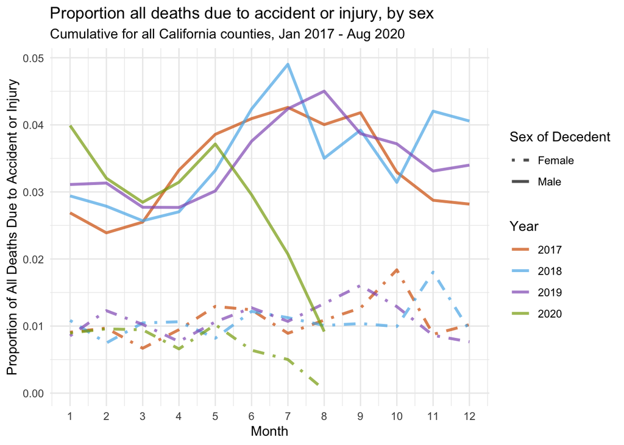

#### Question 20B [0.5 points]:

What do you notice about the trend? Is there anything compelling here? Can you find any possible explanation for what happened in May (month 5) of 2020?

**Answer:** The clearest pattern above plot is that males have a much higher proportion of accident/injury deaths than females in every month and year. the solid male lines sit well above the dashed female ones. The 2017–2019 lines follow a similar seasonal shape. What’s compelling is the 2020 line: it tracks the other years early, peaks around May, then drops sharply month after month, falling far below every other year by August.

The May drop is suspicious, not necessarily real, it could be related stay-at-home orders impact from that time. from this graph alon we couldn’t identify what happened.

### 5.1.2 Mapping injury-related deaths by stay-at-home orders & sex

So, hopefully you’ve noticed what I’ve noticed about the relationship between the stay-at-home orders and the proportion of overall deaths due to accident or injury, as well as the effect of the shutdown in terms of both decedent biological sexes. You know from your earlier graph that females have a lower proportion of overall death due to accident or injury; next, it would be nice to see what the relationship is spatiotemporally (before and after shutdown) on average accident / injury mortality overall, as well as for each of the sexes separately. This will allow you to see if there is a geographic pattern, as one might expect in denser areas with more roadways, with the effect or not.

Let’s add a label to the dataset to identify whether a month was under stay-at-home orders or not, and call the new feature `stayAtHome`. Notice that I could have coded it as a dummy variable (0 or 1) where 1 is the stay-at-home order condition, but instead I chose to encode it as a category. I can also change the encoding later, if needed. Note also that although I chose to use `Date` as the condition for my `ifelse()`, you could just as easily have chosen a joint conditional using both`Month` and `Year` columns!

```r
## Encode stayAtHome as any date after March 19, 2020
injDeaths <- injDeaths %>%
  mutate(stayAtHome = ifelse(Date >= "2020-03-19", "Stay-at-Home", "None"))
```

Next, let’s calculate a summarized dataframe that groups by `stayAtHome`, `Year`, and `County`, then summarizes an average `deathsInjuriesProportion` for use with the maps. Notice that rather than storing the summarized dataframe, I simply piped it through to join it with the geometry from the shapefile for map-making this time. I was feeling a bit lazy.

```r
##### Calculate the proportion of all deaths due to injury
injuryDeathSummary <- injDeaths %>%
  ## Group by stay-at-home order, year, county, AND sex
  group_by(stayAtHome, Year, County, biologicalSex) %>%
  ## Change the name to make the join easier
  rename(COUNTY_NAM = County) %>%
  ## Mean proportion of deaths for each month-year-county-sex combo
  summarise(deathsInjuriesPercent = mean(deathsInjuriesProportion, na.rm = TRUE)*100) %>%
  ## Join to get the geometries for mapping
  full_join(cali_sf, by = "COUNTY_NAM", relationship = "many-to-many") %>%
  ## Coerce to make sure it is seen as a shapefile
  st_as_sf() %>%
  ungroup()

#### Find the five number summary
summ <- fivenum(injuryDeathSummary$deathsInjuriesPercent)
paste0("The five-number summary of % of deaths that are accident/injury-related is: ")
```

```
## [1] "The five-number summary of % of deaths that are accident/injury-related is: "
```

```r
paste(c("Min", "Lower Quartile", "Median", "Upper Quartile", "Max"),
      round(summ, 3))
```

```
## [1] "Min 0"                "Lower Quartile 0"     "Median 0"
## [4] "Upper Quartile 3.306" "Max 18.489"
```

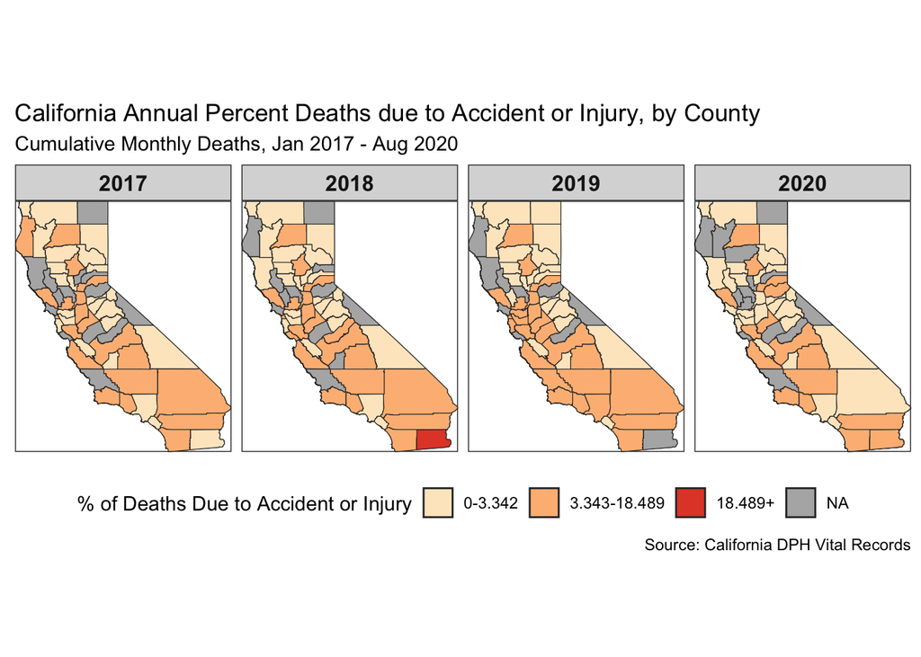

```r
## Notice that, with the minimum, 1st quartile, AND median all equal to 0, we
## really only have three groups

##### Now add on the cuts injuryDeathSummary labels for mapping:
injuryDeathSummary <- injuryDeathSummary %>%
  mutate(deathLabels = cut(deathsInjuriesPercent,
                          breaks = c(0, 3.343, 18.489, Inf),
                          labels = c("0-3.342", "3.343-18.489", "18.489+"),
                          ordered_result = TRUE, right = F))
```

#### Question 21A [0.5 points]::

Do you think there is any evidence that the percent of deaths due to accident & injury changed as a result of the stay-at-home orders? What would provide stronger evidence of a change in percent of deaths due to accident and injury as a result of the shutdown? Do these maps include any evidence of interaction with the sex of the decedent?

**Hint**: Make sure to explain what you would want to do to these maps, either in terms of filtering and/or additional faceting, to better address whether (1) the shutdown has had a likely effect and (2) whether there is an interaction with biological sex on the proportion of deaths due to accident or injury.

**Answer:** From above map, there is no evidence to show that the percent of deaths due to accident & injury changed as a result of the stay-at-home orders. The 2020 panel looks broadly like 2017–2019 — the same mix of cream and orange counties, so there’s no clear visual signal that the order changed injury mortality. also these maps can’t reveal an interaction, because they pool both sexes into one map per year; sex isn’t represented at all.

#### Question 21B [0.5 points]::

Why are some counties filled gray? Are the data truly missing or is it a data maturity problem? Or, is there another reason? (**Hint**: What will happen if the number of deaths in a county are very small?)

**Answer:** The grey counties are NA in the binned variable, but they’re not “missing” in the sense of a failed data pull. They’re a small-numbers problem. These are California’s tiny rural counties — Alpine, Sierra, Mono, Modoc and the like — where very few people die in any given period.

#### Question 21C [3 points]::

Answer one of the two situations you answered in Question 21A. Either make more compelling maps before and after the shutdown OR show interactivity with biological sex, your choice.

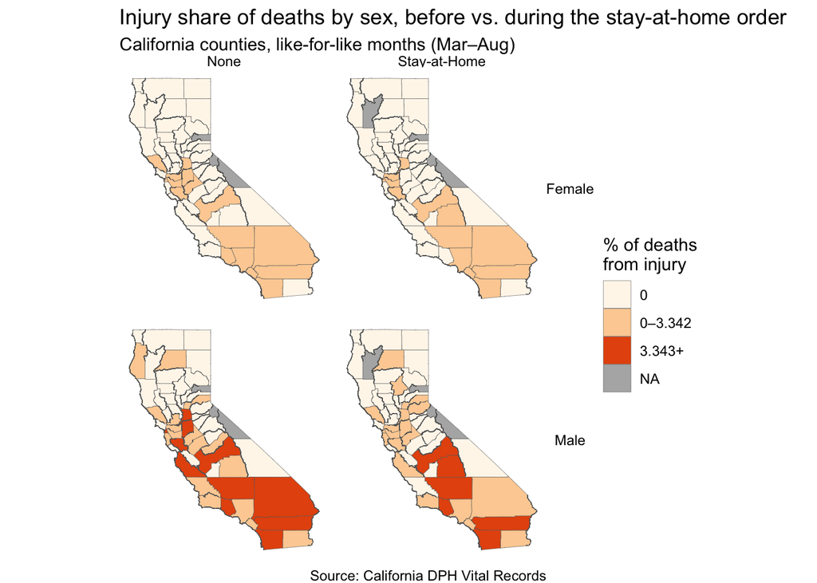

```r
#   COUNTY_NAM, biologicalSex, Month, stayAtHome, an injury-death count, an all-cause count.
injSexMap <- injDeaths %>%
  filter(!is.na(biologicalSex)) %>%               # drop any NA-sex rows from the
  filter(Month %in% 3:8) %>%
  group_by(County, biologicalSex, stayAtHome) %>%
  summarise(
    injuryDeaths = sum(injuryDeaths, na.rm = TRUE),
    totalDeaths  = sum(totalDeaths,  na.rm = TRUE),
    .groups = "drop"
  ) %>%
  mutate(percInjury = ifelse(totalDeaths > 0, injuryDeaths / totalDeaths * 100, NA_real_))

# --- 2. Bin with a dedicated "exactly 0" category (data is zero-inflated) ---
injSexMap <- injSexMap %>%
  mutate(injBin = cut(
    percInjury,
    breaks = c(-Inf, 0, 3.342, Inf),
    labels = c("0", "0\u20133.342", "3.343+"),
    include.lowest = TRUE
  ))

# --- 3. Attach geometry (drop the duplicate Colusa polygon) and map ---
caliGeo <- cali_sf %>% distinct(COUNTY_NAM, .keep_all = TRUE)

injSexSf <- caliGeo %>% left_join(injSexMap, by = c("COUNTY_NAM" = "County"))

ggplot(injSexSf) +
  geom_sf(aes(fill = injBin), color = "grey40", linewidth = 0.1) +
  facet_grid(biologicalSex ~ stayAtHome) +
  scale_fill_manual(
    values  = c("0" = "#FFF7EC", "0\u20133.342" = "#FDD0A2", "3.343+" = "#E6550D"),
    na.value = "grey70",
    name = "% of deaths\nfrom injury"
  ) +
  labs(
    title    = "Injury share of deaths by sex, before vs. during the stay-at-home order",
    subtitle = "California counties, like-for-like months (Mar\u2013Aug)",
    caption  = "Source: California DPH Vital Records"
  ) +
  theme_void()
```

### 5.1.3 Controlling for population-level differences in sex ratio

Even if you didn’t explore biological sex on the map, it seems that there are likely some sex-specific effects in percent of deaths due to accident and injury. But what if some counties have a **skewed sex ratio**? You might need to adjust for that! Although you might expect, *a priori*, for all counties to have a female to male ratio of 1:1, in reality that isn’t always the case.

In order to determine if you need to control for any underlying population-level differences in the sex ratio of each county, you make a simple histogram and plot a 1:1 line where the proportion of females in the population will equal males. You do this for each county. You make a **blue, solid line** for the mean sex-ratio, and a **black, dashed line** to show the reference 1:1 line.

**Note** that this ratio is coming from the Census data that you imported earlier; you calculated this sex ratio in an earlier code chunk from those data. Thus, these data are from 2020.

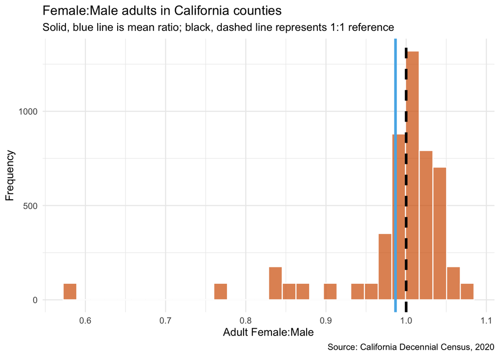

#### Question 22 [1 point]:

Calculate the correlation of `femaleMaleRatio` and the `deathsInjuriesProportion`, making sure to be careful to drop or exclude any NAs before making your calculation.

```r
# Pearson correlation, dropping any row with NA in either variable
cor(injDeaths$femaleMaleRatio,
    injDeaths$deathsInjuriesProportion,
    use = "complete.obs")
```

```
## [1] 0.279791
```

```r
injClean <- injDeaths %>%
  filter(!is.na(femaleMaleRatio), !is.na(deathsInjuriesProportion))

cor.test(injClean$femaleMaleRatio, injClean$deathsInjuriesProportion)
```

```
##
##  Pearson's product-moment correlation
##
## data:  injClean$femaleMaleRatio and injClean$deathsInjuriesProportion
## t = 12.596, df = 1868, p-value < 0.00000000000000022
## alternative hypothesis: true correlation is not equal to 0
## 95 percent confidence interval:
##  0.2374736 0.3210484
## sample estimates:
##      cor
## 0.279791
```

Do you think that this correlation coefficient indicates that you need to make a correction on your maps, or is it likely sufficient just to make the correction in your models? In other words, large correlation coefficients (in the absolute value sense) would indicate a need to correct the maps; smaller coefficients would indicate that it’s probably not a big deal for your visualizations provided to stakeholders.

**Answer:** No, a correlation of 0.28 is small enough that I don’t think the maps need a correction. it’s a weak relationship: the female:male ratio accounts for only about 8% of the variation in the injury-death proportion (0.28² ≈ 0.08), so adjusting every county’s map value for its sex ratio would shuffle the shading only slightly while adding a mathematical step my stakeholders would find hard to follow. The p-value is tiny, but that’s just the large sample size talking, with ~1,870 rows almost any non-zero correlation turns up “significant,” so the effect size, not the p-value, is what should drive this call. So I’ll handle the sex ratio where it’s cheap and transparent. as a predictor in the model and leave the maps as straightforward, uncorrected proportions, noting the caveat in plain language rather than baking in a correction.

#### Question 23 [1 point]:

Now, take a look at the scatter plot below with a best-fit line. Does the plot agree with the correlation coefficient (i.e., direction of slope) you obtained? Why or why not?

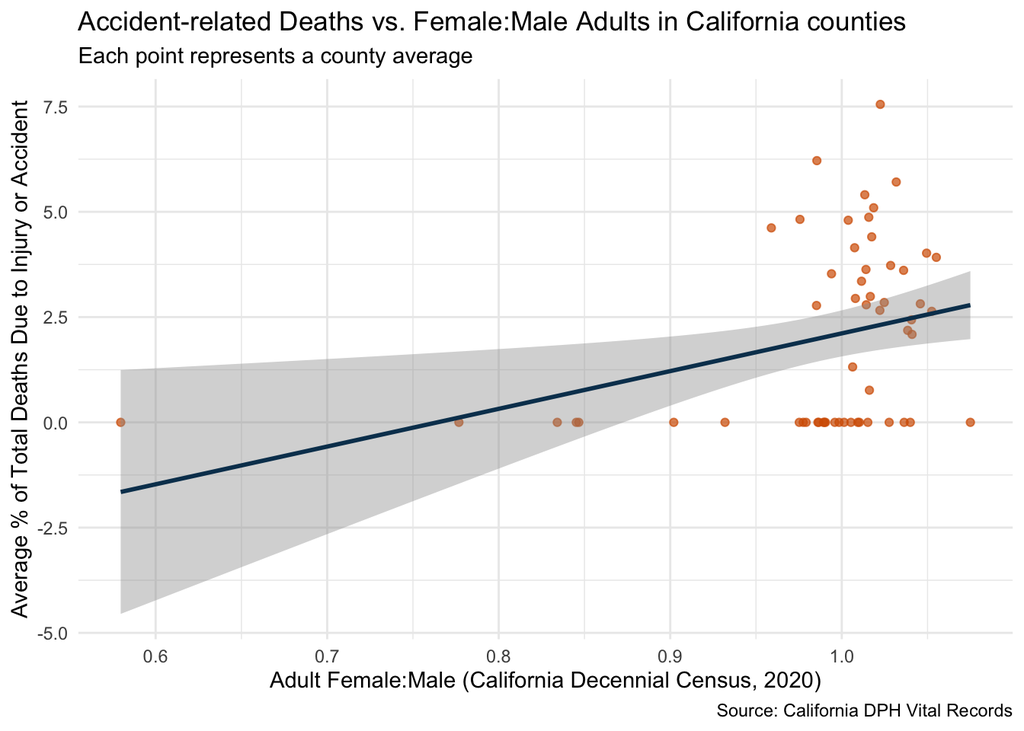

**Answer:** Yes,agrees. The best-fit line slopes upward,positive. which matches the positive correlation of 0.28 I calculated. That agreement isn’t a coincidence: the slope of a simple best-fit line and the sign of a Pearson correlation are always the same thing, because the slope equals r times the ratio of the two standard deviations (slope = r · s_y/s_x), and standard deviations are always positive. So a positive correlation must produce an upward-sloping line， they’re just two ways of expressing the same linear relationship.

#### Question 24 [3 points]:

Originally, I was going to walk you through predictive modeling here as well - but given a need to abbreviate this project, instead I am going to ask you to simply construct **data science question** and **hypothesis** given the information you have here so far. Are there any variables you pulled from the Census that would be worth considering here as well?

Choose what kind of model you would do. Would you include spatial lags? Ideally, would you include temporal lags?

**Answer:**

1. Data science question: Is a county’s sex composition (its female-to-male ratio) a meaningful predictor of the proportion of deaths due to injury or accident, after accounting for spatial structure, temporal structure, and the county’s age profile?
2. Hypothesis: A county’s female-to-male ratio is associated with its injury/accident death proportion, but based on the weak bivariate correlation I found earlier (r = 0.28, and in the opposite direction from the demographic intuition), I expect any effect to be small, and quite possibly to weaken or disappear once age structure and spatial/temporal autocorrelation are accounted for. So I’m really testing not just whether sex ratio is a significant predictor (with this many observations, almost anything is) but whether it’s a meaningful one.
3. Model: I would include spatial lags, definitely. The counties are largely arbitrary boundaries, so include some info between neighbors through a spatial lag should better capture the actual spatial trends. I’d try multiple models, starting with a SAR model and then exploring an SEM if the diagnostics point to spatial error rather than a spatial lag. I would also include temporal lags: in the earlier random-forest work, recent mortality was the single strongest predictor, so a county’s recent injury history likely carries real month-to-month momentum though I’d watch that the lags don’t absorb the very signal I’m trying to measure. Beyond that, I’d add more demographic predictors from the Census (age structure, especially % over 65, is the strongest one I already have; true socioeconomic variables like income or education would need an additional Census pull). Increasing the complexity that way would also let me try a decision-tree model like Random Forest and see how it compares with the added benefit that its variable-importance metrics could shed light directly on where sex ratio ranks against the other predictors.

## 5.2 Choose your own cause-of-death to explore.

#### Question 25 [15 points]:

Now for the choose your own adventure portion of this assignment! Table 2 gives you a list of ICD-10 codes for the causes of death available in the dataset. You should be able to use the code in Section 5.1, with minimal adjustment, to explore your data.

Feel free to get creative! You are not required to continue stratifying by sex, unless you want to; in the Census data you pulled, you also have stratifications by **retirement age status** (over 65 years) or **double-stratified by both sex and retirement age**. You may also choose not to use any stratification if you wish.

##### For full credit, I will be looking for:

```r
## Pull just the PNF rows and collapse the two sex rows into one count per county-month
pnfDeaths <- sexDeaths %>%
  full_join(census, by = "County") %>%
  ## Here is where you filter for a specific cause of death relative to sex
  filter(leadingCauseDeath == "PNF") %>%
  full_join(totalDeaths[ , 1:4], by = c("County", "Year", "Month")) %>%
  rename(pneumoniaDeaths = sexDeaths) %>%
  ## Calculate the proportion of all deaths that are from injury
  mutate(deathsPnfProportion = pneumoniaDeaths/totalDeaths,
         ## The ratio of females to males in the population
         femaleMaleRatio = femalesN/malesN,
         ## The ratio of 65+ females to males in the population
         femaleMaleRatio65 = females65plus/males65plus,
         ## Ratio of retirees to non-retirees
         retireeRatio = over65/totalN,
         ## Convert the date to a date format for plotting
         Date = as.Date(paste(Year, Month, "1", sep = "-"),
                        format = "%Y-%m-%d")) %>%
         ## Illegal div by 0 turned to NaN; turn back to 0
  mutate(deathsPnfProportion = ifelse(deathsPnfProportion == "NaN",  0, deathsPnfProportion))

## ---- sanity checks ----
nrow(pnfDeaths)
```

```
## [1] 5104
```

```r
n_distinct(pnfDeaths$County)
```

```
## [1] 58
```

```r
summary(pnfDeaths$deathsPnfProportion * 100)   # as a percent
```

```
##    Min. 1st Qu.  Median    Mean 3rd Qu.    Max.    NA's
##  0.0000  0.0000  0.0000  0.3657  0.0000  5.8511    2981
```

```r
sum(is.na(pnfDeaths$deathsPnfProportion))       # how many suppressed/NA at the row
```

```
## [1] 2981
```

1. **Annual chloropeth maps showing your cause-of-death**, like this one

```r
## A. collapse sex-split rows to one clean row per county-month
pnfMonthly <- pnfDeaths %>%
  group_by(County, Year, Month) %>%
  summarise(pnfDeaths   = sum(pneumoniaDeaths, na.rm = TRUE),  # over both sexes
            totalDeaths = first(totalDeaths),                     # both-sex total (don't double-count)
            .groups = "drop")

## B. aggregate to county-YEAR and compute the annual %
pnfAnnual <- pnfMonthly %>%
  group_by(County, Year) %>%
  summarise(pnfDeaths   = sum(pnfDeaths,   na.rm = TRUE),
            totalDeaths = sum(totalDeaths, na.rm = TRUE),
            .groups = "drop") %>%
  mutate(deathsPnfPercent = ifelse(totalDeaths > 0, pnfDeaths / totalDeaths * 100, NA_real_)) %>%
  rename(COUNTY_NAM = County)

## C. bin the continuous % into map categories
summ <- fivenum(pnfAnnual$deathsPnfPercent)
paste(c("Min","Lower Quartile","Median","Upper Quartile","Max"), round(summ, 3))
```

```
## [1] "Min 0"                "Lower Quartile 0"     "Median 0"
## [4] "Upper Quartile 0.465" "Max 3.415"
```

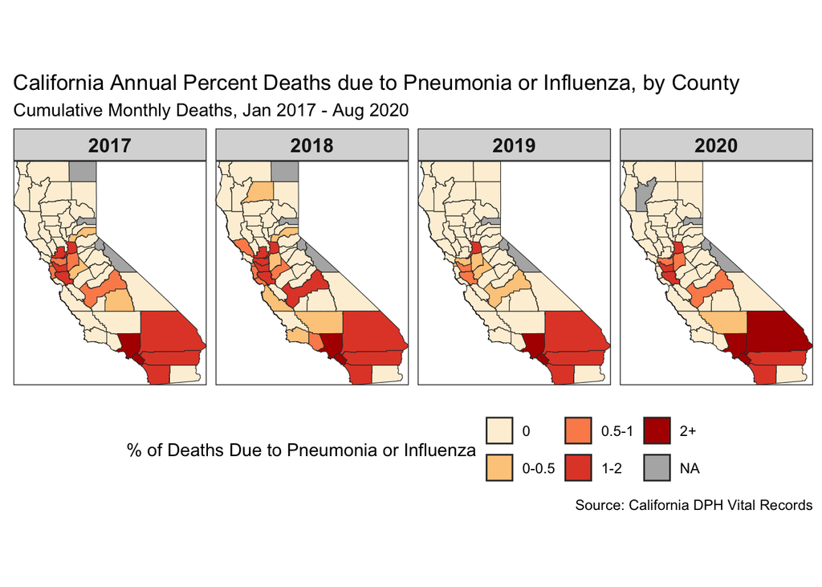

```r
pnfAnnual <- pnfAnnual %>%
  mutate(deathLabels = cut(deathsPnfPercent,
                           breaks = c(-Inf, 0, 0.5, 1, 2, Inf),
                           labels = c("0", "0-0.5", "0.5-1", "1-2", "2+"),
                           include.lowest = TRUE))

## D. attach the county polygons
caliGeo     <- cali_sf %>% distinct(COUNTY_NAM, .keep_all = TRUE)
pnfAnnualSf <- pnfAnnual %>%
  full_join(caliGeo, by = "COUNTY_NAM", relationship = "many-to-many") %>%
  st_as_sf()

## E. draw one map per year
ggplot(pnfAnnualSf) +
  geom_sf(aes(fill = deathLabels), color = "gray20", size = 0.2) +
  scale_fill_manual(name = "% of Deaths Due to Pneumonia or Influenza",
                    values = c4a(palette = "brewer.or_rd", n = 5),
                    na.value = "gray70", drop = FALSE) +
  coord_sf(expand = FALSE) +
  theme_bw() +
  theme(panel.grid = element_blank(), axis.text = element_blank(),
        axis.ticks = element_blank(), axis.title = element_blank(),
        strip.text = element_text(size = 12, face = "bold"),
        legend.position = "bottom") +
  labs(title = "California Annual Percent Deaths due to Pneumonia or Influenza, by County",
       subtitle = "Cumulative Monthly Deaths, Jan 2017 - Aug 2020",
       caption = "Source: California DPH Vital Records") +
  facet_wrap(~ Year, ncol = 4)
```

2. **A line graph showing changes, by month and year, in your cause-of-death**, somewhat like this one with stratification *optional*

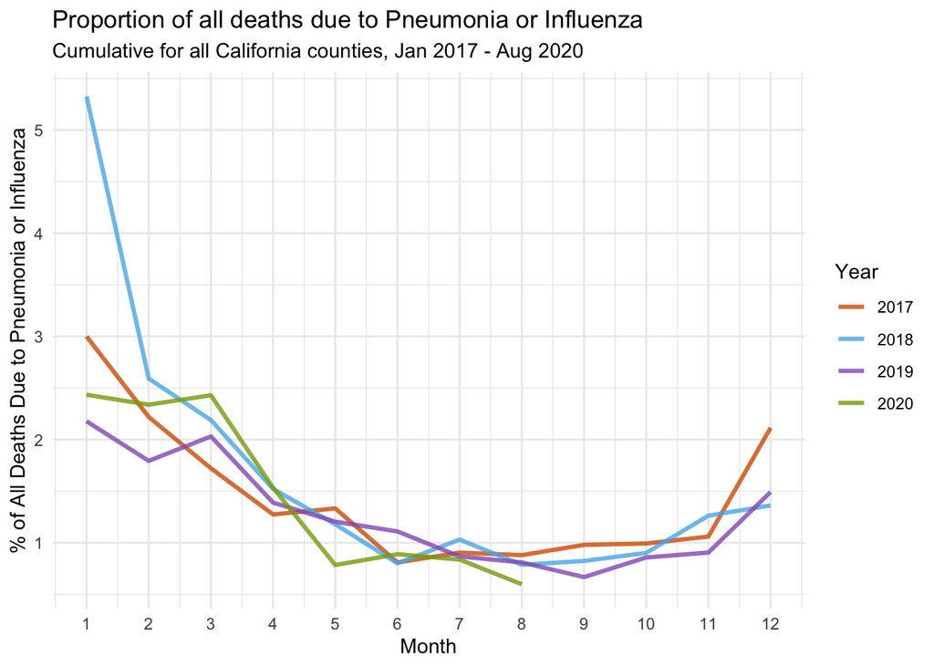

```r
pnfMonthly %>%
  group_by(Year, Month) %>%
  summarise(deathsPnfPercent = sum(pnfDeaths, na.rm = TRUE) /
                               sum(totalDeaths, na.rm = TRUE) * 100,
            .groups = "drop") %>%
  ggplot(aes(x = Month, y = deathsPnfPercent, color = as.factor(Year))) +
  geom_line(alpha = 0.8, size = 1.1) +
  scale_x_continuous(n.breaks = 12) +
  scale_color_manual(values = skittles[c(5, 9:11)]) +
  labs(title    = "Proportion of all deaths due to Pneumonia or Influenza",
       subtitle = "Cumulative for all California counties, Jan 2017 - Aug 2020",
       y = "% of All Deaths Due to Pneumonia or Influenza",
       x = "Month", color = "Year") +
  theme_minimal()
```

3. **At least one other form of exploration to form a testable question or hypothesis, including but not limited to:**
- A correlation test
- A scatterplot
- Stratified boxplots
- Feel free to be creative!

```r
correlationValue <- pnfDeaths %>%
  filter(!is.na(retireeRatio), !is.na(deathsPnfProportion)) %>%
  summarise(cor = cor(retireeRatio, deathsPnfProportion)) %>%
  pull(cor)
correlationValue
```

```
## [1] -0.3789419
```